# February_updates

#### 5.1.2.7 ATC-ATA

```
## [1] "motif_1"
## [1] "ATC"
## [1] "ATA"
## 3-letter DNAString object
## seq: TAT
```

```
## [1] "motif_4"
## [1] "ATC"
## [1] "ATA"
## 3-letter DNAString object
## seq: TAT
```

```
## [1] "motif_2"
## [1] "ATC"
## [1] "ATA"
## 3-letter DNAString object
## seq: TAT
```

```
## [1] "motif_6"
## [1] "ATC"
## [1] "ATA"
## 3-letter DNAString object
## seq: TAT
```

```
## [1] "motif_5"
## [1] "ATC"
## [1] "ATA"
## 3-letter DNAString object
## seq: TAT
```

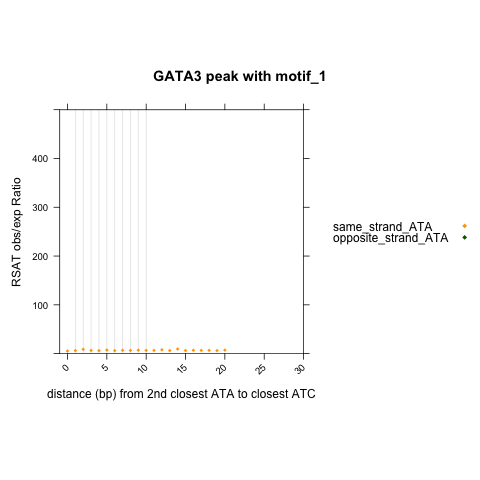

Figure 29: xy plot of rsat analysis for GATA3 peak with motif12456: 3mer structure

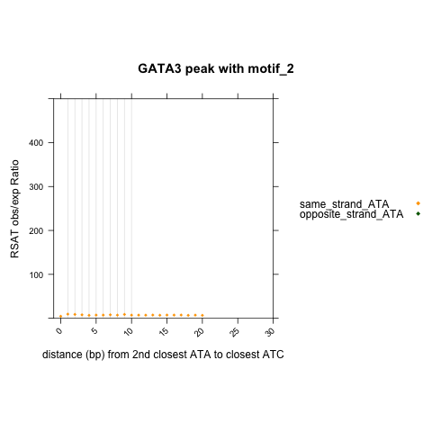

Figure 30: xy plot of rsat analysis for GATA3 peak with motif12456: 3mer structure

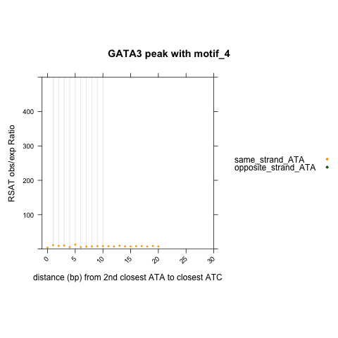

Figure 31: xy plot of rsat analysis for GATA3 peak with motif12456: 3mer structure

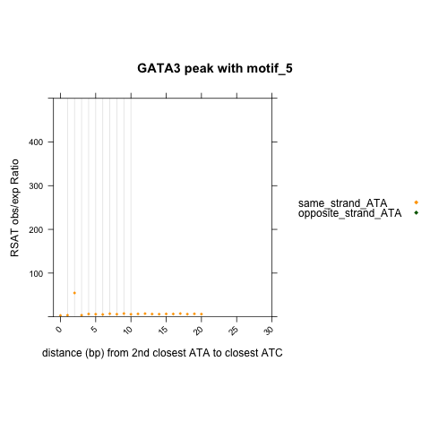

Figure 32: xy plot of rsat analysis for GATA3 peak with motif12456: 3mer structure

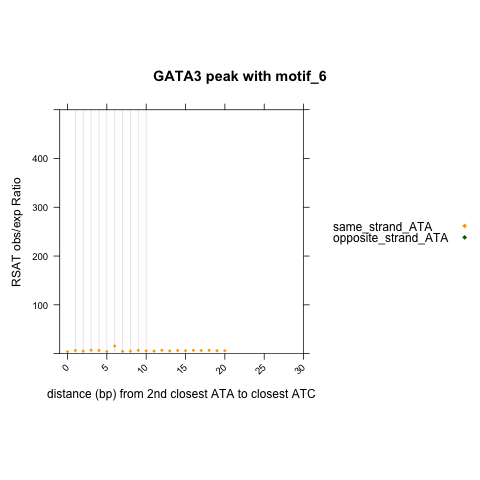

Figure 33: xy plot of rsat analysis for GATA3 peak with motif12456: 3mer structure

```r
library(lattice)
library(latticeExtra)
library(Biostrings)
my_motifs = c("motif_1", "motif_4","motif_2", "motif_6", "motif_5")
Anchor_dyad = c("ATC")
Query_dyad =c("ATA")
compute_dis_df=read.csv('pattern_anchor_at_G_compute_dis.csv')

for (motif in my_motifs) {
  print(motif)
  rsat_results=paste0("GATA3_peak_161win_with_", motif, "_RSAT_dyad.txt")
  for (pattern1 in Anchor_dyad){
    print(pattern1)
    for (pattern2 in Query_dyad){
      print(pattern2)
      number1=compute_dis_df[compute_dis_df$pattern==pattern1, "anchor"] + compute_dis_df[compute_dis_df$pattern==pattern2, "query"]
      rc_pattern2=reverseComplement(DNAString(pattern2))
      print(rc_pattern2)
      number2=compute_dis_df[compute_dis_df$pattern==pattern1, "anchor"] + compute_dis_df[compute_dis_df$pattern==as.character(rc_pattern2), "query"]

      ss <- process_and_subset_RSAT(rsat_results, pattern1, pattern2, number1)
      os <- process_and_subset_RSAT(rsat_results, pattern1, rc_pattern2, number2)

      if(nrow(ss) > 0) {
                        ss$query_status <- paste0("same_strand_", pattern2)
                        } else {
                        ss <- data.frame(matrix(NA, ncol = ncol(ss), nrow = 1)) # Fill ss dataframe with NA values for all columns
                        colnames(ss) <- c("first", "dyad_distance", "second", "ratio","relative_distance")
                        ss$query_status <- paste0("same_strand_", pattern2)
                        }

      if(nrow(os) > 0) {
                        os$query_status <- paste0("opposite_strand_", pattern2)
                        } else {
                        os <- data.frame(matrix(NA, ncol = ncol(os), nrow = 1)) # Fill os dataframe with NA values for all columns
                        colnames(os) <- c("first", "dyad_distance", "second", "ratio","relative_distance")
                        os$query_status <- paste0("opposite_strand_", pattern2)
                        }

      df.plot=rbind(ss, os)
      df.plot$query_status = factor(df.plot$query_status, levels = c(paste0("same_strand_", pattern2), paste0("opposite_strand_", pattern2)))

      # xy plot
      png(paste0('xy_RSAT_dyad_closest_2nd_', pattern2, '_to_closest_1st_', pattern1, '_to_GATA3_pos_', motif, '_compare_to_DHS.png'))
      print(xyplot(ratio ~ relative_distance,
                   data = df.plot,
                   groups = query_status,
                   auto.key=list(space="right", points=TRUE),
                   aspect = 1,
                   xlim=c(-1,30),
                   ylim=c(0, 500),
                   xlab = paste0("distance (bp) from 2nd closest ",pattern2, " to closest ", pattern1),
                   ylab="RSAT obs/exp Ratio",
                    main=paste0("GATA3 peak with ", motif),
                   between=list(y=1.0),
                   scales = list(x = list(rot = 45, at = seq(from = 0, to = 50, by = 5))),
                   par.settings = list(superpose.symbol = list(col=c("orange", "darkgreen"), pch=18, lwd=2), strip.background=list(col="grey85")),
                   panel = function(x,y,...) {panel.abline(v=c(seq(1, 10, 1)), col = "grey90")
                                              panel.xyplot(x, y,
                                                           col=c("orange","darkgreen"),
                                                           pch=18,
                                                           cex=0.6,...)
                                              #panel.barchart(x,y, horizontal = FALSE, col=c("red", "blue"), alpha=0.4)


                 }))
     dev.off()
    }
  }
}
```

In these graph, we also did not see structure of ATC-TAT(opposite strand ATA). And only see one enriched structure for ATC-ATA at relative distance==2bp. This structure must be ATCxGATA, which match with motif5.

#### 5.1.2.8 GAT-ATA

```
## [1] "motif_1"
## [1] "GAT"
## [1] "ATA"
## 3-letter DNAString object
## seq: TAT
```

```
## [1] "motif_4"
## [1] "GAT"
## [1] "ATA"
## 3-letter DNAString object
## seq: TAT
```

```
## [1] "motif_2"
## [1] "GAT"
## [1] "ATA"
## 3-letter DNAString object
## seq: TAT
```

```
## [1] "motif_6"
## [1] "GAT"
## [1] "ATA"
## 3-letter DNAString object
## seq: TAT
```

```
## [1] "motif_5"
## [1] "GAT"
## [1] "ATA"
## 3-letter DNAString object
## seq: TAT
```

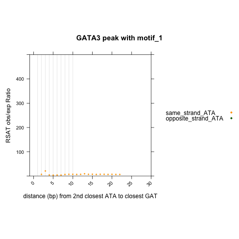

Figure 34: xy plot of rsat analysis for GATA3 peak with motif12456: 3mer structure

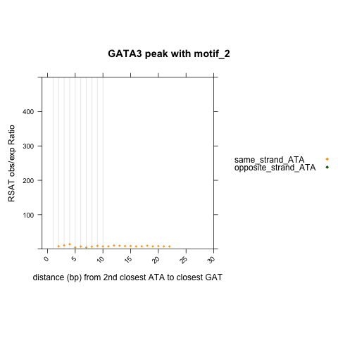

Figure 35: xy plot of rsat analysis for GATA3 peak with motif12456: 3mer structure

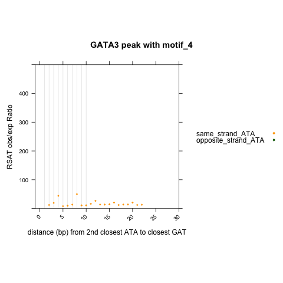

Figure 36: xy plot of rsat analysis for GATA3 peak with motif12456: 3mer structure

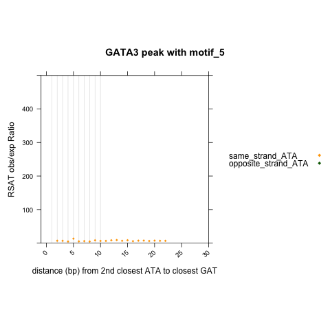

Figure 37: xy plot of rsat analysis for GATA3 peak with motif12456: 3mer structure

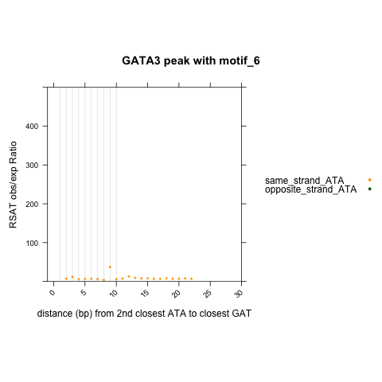

Figure 38: xy plot of rsat analysis for GATA3 peak with motif12456: 3mer structure

```r
library(lattice)
library(latticeExtra)
library(Biostrings)
my_motifs = c("motif_1", "motif_4","motif_2", "motif_6", "motif_5")
Anchor_dyad = c("GAT")
Query_dyad =c("ATA")
compute_dis_df=read.csv('pattern_anchor_at_G_compute_dis.csv')

for (motif in my_motifs) {
  print(motif)
  rsat_results=paste0("GATA3_peak_161win_with_", motif, "_RSAT_dyad.txt")
  for (pattern1 in Anchor_dyad){
    print(pattern1)
    for (pattern2 in Query_dyad){
      print(pattern2)
      number1=compute_dis_df[compute_dis_df$pattern==pattern1, "anchor"] + compute_dis_df[compute_dis_df$pattern==pattern2, "query"]
      rc_pattern2=reverseComplement(DNAString(pattern2))
      print(rc_pattern2)
      number2=compute_dis_df[compute_dis_df$pattern==pattern1, "anchor"] + compute_dis_df[compute_dis_df$pattern==as.character(rc_pattern2), "query"]

      ss <- process_and_subset_RSAT(rsat_results, pattern1, pattern2, number1)
      os <- process_and_subset_RSAT(rsat_results, pattern1, rc_pattern2, number2)

      if(nrow(ss) > 0) {
                        ss$query_status <- paste0("same_strand_", pattern2)
                        } else {
                        ss <- data.frame(matrix(NA, ncol = ncol(ss), nrow = 1)) # Fill ss dataframe with NA values for all columns
                        colnames(ss) <- c("first", "dyad_distance", "second", "ratio","relative_distance")
                        ss$query_status <- paste0("same_strand_", pattern2)
                        }

      if(nrow(os) > 0) {
                        os$query_status <- paste0("opposite_strand_", pattern2)
                        } else {
                        os <- data.frame(matrix(NA, ncol = ncol(os), nrow = 1)) # Fill os dataframe with NA values for all columns
                        colnames(os) <- c("first", "dyad_distance", "second", "ratio","relative_distance")
                        os$query_status <- paste0("opposite_strand_", pattern2)
                        }

      df.plot=rbind(ss, os)
      df.plot$query_status = factor(df.plot$query_status, levels = c(paste0("same_strand_", pattern2), paste0("opposite_strand_", pattern2)))

      # xy plot
      png(paste0('xy_RSAT_dyad_closest_2nd_', pattern2, '_to_closest_1st_', pattern1, '_to_GATA3_pos_', motif, '_compare_to_DHS.png'))
      print(xyplot(ratio ~ relative_distance,
                   data = df.plot,
                   groups = query_status,
                   auto.key=list(space="right", points=TRUE),
                   aspect = 1,
                   xlim=c(-1,30),
                   ylim=c(0, 500),
                   xlab = paste0("distance (bp) from 2nd closest ",pattern2, " to closest ", pattern1),
                   ylab="RSAT obs/exp Ratio",
                    main=paste0("GATA3 peak with ", motif),
                   between=list(y=1.0),
                   scales = list(x = list(rot = 45, at = seq(from = 0, to = 50, by = 5))),
                   par.settings = list(superpose.symbol = list(col=c("orange", "darkgreen"), pch=18, lwd=2), strip.background=list(col="grey85")),
                   panel = function(x,y,...) {panel.abline(v=c(seq(1, 10, 1)), col = "grey90")
                                              panel.xyplot(x, y,
                                                           col=c("orange","darkgreen"),
                                                           pch=18,
                                                           cex=0.6,...)
                                              #panel.barchart(x,y, horizontal = FALSE, col=c("red", "blue"), alpha=0.4)


                 }))
     dev.off()
    }
  }
}
```

Notice that we again did not see dyad structures of GAT-TAT(opposite stand ATA), but has identified enriched structure of GAT-ATA for GATA3 peaks with motif4 and motif6.

For GATA3 peaks with motif4, we see gatn{6}ata and gatn{2}ata enriched. The relative distance between two zinc fingers is 8bp and 4bp. The 8bp one match with moyif4, the 4bp one match with GATAGATA.  
For GATA3 peaks with motif6, we see gatn{7}ata enriched, the relative distance between two zinc fingers is 9bp. This match with motif6 PWMs.

**For the added 2 pairs of 3mer**:

I have add the relative distance to the pattern_anchor_at_G_compute_dis.csv file.

```bash
pattern identifier anchor query
AGA AGA(t)  2   1
TCT (a)TCT  2   1
TAG (ga)TAG 5   -2
CTA CTA(tc) -1  4
```

### 5.1.3 Summary

Overall, RSAT-dyad analysis proves effective in identifying enriched binding elements within a set of peak regions, with proper controls and parameter settings.

Enriched dyad structures can be discerned through various combinations of 3-mers. Establishing the relative distance between zinc fingers serves as a valuable method to determine if a structure arises from the same binding element.

## 5.2 Customized analysis – prioritized 3mer

### 5.2.1 Closest 3mer to peak summits

**Goal: given a prioritized 3mer list, we can generate the closest 3mer coordinates to a given sets of peak summits.**

240208_closestBed.R:

(cd /home/FCAM/ssun/GATA3_ChIP_PRO_July2023/ChIP_final/GAT_3mer_analaysis/closest_other_3mer)

```r
#!/usr/bin/env Rscript

Args=commandArgs(TRUE)
# closestBed function
bedTools.closest <- function(functionstring="/home/FCAM/ssun/packages/bedtools2/bin/closestBed",bed1,bed2,opt.string="") {

  options(scipen =99) # not use scientific notation when writing out

  #write bed formatted data.frames to tempfile
  write.table(bed1,file= 'a.file.bed', quote=F,sep="\t",col.names=F,row.names=F)
  write.table(bed2,file= 'b.file.bed', quote=F,sep="\t",col.names=F,row.names=F)

  # create the command string and call the command using system()
  # the command sort a and b file by coordinates
  command1=paste('sort -k1,1 -k2,2n', 'a.file.bed', '> a.file.sorted.bed')
  cat(command1,"\n") #sort -k1,1 -k2,2n a.file.bed > a.file.sorted.bed
  try(system(command1))
  command2=paste('sort -k1,1 -k2,2n', 'b.file.bed', '> b.file.sorted.bed')
  cat(command2,"\n")
  try(system(command2))

  # the command call closestBed on bed1 and bed2
  command=paste(functionstring, opt.string,"-a",'a.file.sorted.bed',"-b",'b.file.sorted.bed',">",'out.file.bed',sep=" ")
  cat(command,"\n")
  try(system(command))

  res=read.table('out.file.bed',header=F, comment.char='')

  # remove intermediate files
  command3=paste('rm', 'a.file.bed', 'b.file.bed', 'a.file.sorted.bed', 'b.file.sorted.bed', 'out.file.bed')
  cat(command3,"\n")
  try(system(command3))

  colnames(res) = c(colnames(bed1), colnames(bed2), 'dis' )
  return(res)
}

dir1="/labs/Guertin/siyu/Sathyan_GATA3_ChIP_pool1_pool2/overrep_3mer/hg38_full_kmer3_rs1000/seqdump/"
dir2="/home/FCAM/ssun/GATA3_ChIP_PRO_July2023/ChIP_final/GAT_3mer_analaysis/MAST_positive_control/"
dir3="/home/FCAM/ssun/GATA3_ChIP_PRO_July2023/ChIP_final/GAT_3mer_analaysis/ENCODE_DHS_GSE29692/"
my_motifs = c("motif_1", "motif_4","motif_2", "motif_6", "motif_5")
prioritized_triplets = c("AAA", "TAA" ,"ATA" ,"TTA", "AAT", "TAT", "GAT", "ATT", "TTT", "ATC", "AGA", "TCT", "TAG", "CTA")
library(bigWig)

for (triplet in prioritized_triplets){
  print(triplet)
  # 3mer genome coordinates
  plus.triplet.file=read.table(file = Sys.glob(file.path(paste0(dir1,"hg38.3.3.3plus.*_",triplet, ".bed"))), sep="\t", header=FALSE)
  minus.triplet.file=read.table(file = Sys.glob(file.path(paste0(dir1,"hg38.3.3.3minus.*_",triplet ,".bed"))), sep="\t", header=FALSE)
  for (motif in my_motifs){
    print(motif)
    # peak summits
    GATA3_peak_summits=center.bed(read.table(paste0(dir2, "GATA3_peak_161win_with_",motif, ".bed"), header=FALSE), upstreamWindow = 0, downstreamWindow = 0)
    # consensus neg
    indep.DHS.control.consensus=center.bed(read.table(paste0(dir3, "MCF7DHS_consensus_noGATA_without_motifs_123456_78.bed"), header=FALSE), upstreamWindow = 0, downstreamWindow = 0)

    # closestBed--1st closest plus

    ##
    closest.1st.plus.triplet.to.peak=bedTools.closest(bed1 = GATA3_peak_summits[,1:3], bed2 = plus.triplet.file, opt.string = '-d -t first')
    write.table(closest.1st.plus.triplet.to.peak,file= paste0('closest.1st.plus.',triplet,'.to.GATA3.with.', motif,'.bed'), quote=F,sep="\t",col.names=F,row.names=F)

    ##
    closest.1st.plus.triplet.to.indep.DHS.control.consensus=bedTools.closest(bed1 = indep.DHS.control.consensus[,1:3], bed2 = plus.triplet.file, opt.string = '-d -t first')
    write.table(closest.1st.plus.triplet.to.indep.DHS.control.consensus,file= paste0('closest.1st.plus.',triplet,'.to.indep.DHS.control.consensus.bed'), quote=F,sep="\t",col.names=F,row.names=F)

     # closestBed--1st closest minus

     ##
     closest.1st.minus.triplet.to.peak=bedTools.closest(bed1 = GATA3_peak_summits[,1:3], bed2 =minus.triplet.file, opt.string = '-d -t first')
     write.table(closest.1st.minus.triplet.to.peak,file= paste0('closest.1st.minus.',triplet,'.to.GATA3.with.', motif,'.bed'), quote=F,sep="\t",col.names=F,row.names=F)

     ##
     closest.1st.minus.triplet.to.indep.DHS.control.consensus=bedTools.closest(bed1 = indep.DHS.control.consensus[,1:3], bed2 = minus.triplet.file, opt.string = '-d -t first')
    write.table(closest.1st.minus.triplet.to.indep.DHS.control.consensus,file= paste0('closest.1st.minus.',triplet,'.to.indep.DHS.control.consensus.bed'), quote=F,sep="\t",col.names=F,row.names=F)

  }

}
```

runR.sh

```bash
#!/bin/bash
#SBATCH --job-name=runR.sh     # name for job
#SBATCH -N 1
#SBATCH -n 1
#SBATCH -c 8
#SBATCH -p general
#SBATCH --qos=general
#SBATCH --mem=200G
#SBATCH --mail-type=ALL
#SBATCH --mail-user=ssun@uchc.edu
#SBATCH -o runR.sh_%j.out
#SBATCH -e runR.sh_%j.err

module load R/4.1.2
Rscript 240208_closestBed.R
```

### 5.2.2 2nd closest 3mer to the anchor 3mer

**Overall Goal: given the closest 3mer coordinates file, we can loop through a set of 3mer list and generate the 2nd closest 3mer coordinates to the provided closest 3mer coordinates.**

#### 5.2.2.1 sort the 3mer genome coordinates

sort_3mer_cor.sh

```bash
#!/bin/bash
#SBATCH --job-name=sort_3mer_cor.sh
#SBATCH -N 1
#SBATCH -n 1
#SBATCH -c 4
#SBATCH -p general
#SBATCH --qos=general
#SBATCH --mem=32G
#SBATCH --mail-type=ALL
#SBATCH --mail-user=ssun@uchc.edu
#SBATCH -o sort_3mer_cor.sh_%j.out
#SBATCH -e sort_3mer_cor.sh_%j.err

hostname
name=XXXXXX

input_dir1=/labs/Guertin/siyu/Sathyan_GATA3_ChIP_pool1_pool2/overrep_3mer/hg38_full_kmer3_rs1000/seqdump/

sort -k1,1 -k2,2n ${input_dir1}hg38.3.3.3${name}.bed > hg38.3.3.3${name}.sorted.bed
```

```bash
file=sort_3mer_cor.sh

for i in hg38.3.3.3*.bed
do
    nm=$(echo $i | awk -F"/" '{print $NF}' | awk -F"hg38.3.3.3" '{print $2}' | awk -F".bed" '{print $1}')
    echo $nm
    sed -e "s/XXXXXX/${nm}/g" "$file" > sort_hg38.3.3.3${nm}.sh
    sbatch sort_hg38.3.3.3${nm}.sh
    sleep 1
done
```

#### 5.2.2.2 check if `bedtools subtract` change the internal order of file

```bash
#ls /labs/Guertin/siyu/Sathyan_GATA3_ChIP_pool1_pool2/overrep_3mer/hg38_full_kmer3_rs1000/seqdump/*.sorted.bed
#subset a test file
awk '$1 == "chr4"' /labs/Guertin/siyu/Sathyan_GATA3_ChIP_pool1_pool2/overrep_3mer/hg38_full_kmer3_rs1000/seqdump/hg38.3.3.3plus.36_GAT.sorted.bed > hg38.3.3.3plus.36_GAT_subset_chr4.sorted.bed

wc -l hg38.3.3.3plus.36_GAT_subset_chr4.sorted.bed #2583363

wc -l /home/FCAM/ssun/GATA3_ChIP_PRO_July2023/ChIP_final/GAT_3mer_analaysis/closest_other_3mer/closest.1st.plus.GAT.to.GATA3.with.motif_1.bed #12470

awk '{print $4, $5, $6, $7, $8, $9, $10}' /home/FCAM/ssun/GATA3_ChIP_PRO_July2023/ChIP_final/GAT_3mer_analaysis/closest_other_3mer/closest.1st.plus.GAT.to.GATA3.with.motif_1.bed  | awk '{$1=$1}1' OFS="\t" | uniq | sort -k1,1 -k2,2n > closest.1st.plus.GAT.to.GATA3.with.motif_1.uniq.sorted.bed

wc -l closest.1st.plus.GAT.to.GATA3.with.motif_1.uniq.sorted.bed #12461 #less than the original file because original file has two different peaks assigned with same closest 3mer coordinates

module load bedtools

bedtools subtract -a hg38.3.3.3plus.36_GAT_subset_chr4.sorted.bed -b closest.1st.plus.GAT.to.GATA3.with.motif_1.uniq.sorted.bed -f 1.00 -s > substract_output.bed #2582612

sort -k1,1 -k2,2n substract_output.bed > substract_output.sorted.bed

diff substract_output.bed substract_output.sorted.bed
# no output printed on the screen, the two file are the same.
```

`bedtools subtract` does not change the order of the input files.

#### 5.2.2.3 For each 3mer genome coordinates, remove the identified closest 3mer on the same strand

**Remove the first closest GAT with `bedtools subtract`**  
Subtract the 1st closest GAT from all.GAT, then find the closest 2nd GAT to the closest 1st GAT.  
`-f` Requiring a minimal overlap fraction before subtracting. Here we define `-f 1.00` to make sure of a 100% overlap between two file before subtracting.  
`-s` Enforcing same “strandedness” while scanning for features in `-b file` that should be subtracted from `-a file`.

```bash
#!/bin/bash
#SBATCH --job-name=remove_1st_3mer.sh     # name for job
#SBATCH -N 1
#SBATCH -n 1
#SBATCH -c 16
#SBATCH -p general
#SBATCH --qos=general
#SBATCH --mem=200G
#SBATCH --mail-type=ALL
#SBATCH --mail-user=ssun@uchc.edu
#SBATCH -o remove_1st_3mer.sh_%j.out
#SBATCH -e remove_1st_3mer.sh_%j.err


input_dir1=/labs/Guertin/siyu/Sathyan_GATA3_ChIP_pool1_pool2/overrep_3mer/hg38_full_kmer3_rs1000/seqdump/
input_dir2=/home/FCAM/ssun/GATA3_ChIP_PRO_July2023/ChIP_final/GAT_3mer_analaysis/closest_other_3mer/

#output_dir=/home/FCAM/ssun/GATA3_ChIP_PRO_July2023/ChIP_final/GAT_3mer_analaysis/closest_other_3mer/closest_2nd_other_3mer/

my_motifs=("motif_1" "motif_2" "motif_4" "motif_5" "motif_6")
prioritized_triplets=("AAA" "TAA" "ATA" "TTA" "AAT" "TAT" "GAT" "ATT" "TTT" "ATC" "AGA" "TCT" "TAG" "CTA")

# Use a for loop to iterate over the
module load bedtools
for triplet in "${prioritized_triplets[@]}"
do
  echo $triplet

  for motif in "${my_motifs[@]}"
  do
    echo $motif
    # plus
    awk '{print $4, $5, $6, $7, $8, $9, $10}' ${input_dir2}closest.1st.plus.${triplet}.to.GATA3.with.${motif}.bed  | awk '{$1=$1}1' OFS="\t" | uniq | sort -k1,1 -k2,2n > closest.1st.plus.${triplet}.to.GATA3.with.${motif}.uniq.sorted.bed

    bedtools subtract -a ${input_dir1}hg38.3.3.3plus.${triplet}.sorted.bed -b closest.1st.plus.${triplet}.to.GATA3.with.${motif}.uniq.sorted.bed -f 1.00 -s > hg38.3.3.3plus.${triplet}_without_1st_plus_${triplet}_to_GATA3_with_${motif}.bed

    rm closest.1st.plus.${triplet}.to.GATA3.with.${motif}.uniq.sorted.bed

    # minus
    awk '{print $4, $5, $6, $7, $8, $9, $10}' ${input_dir2}closest.1st.minus.${triplet}.to.GATA3.with.${motif}.bed  | awk '{$1=$1}1' OFS="\t" | uniq | sort -k1,1 -k2,2n > closest.1st.minus.${triplet}.to.GATA3.with.${motif}.uniq.sorted.bed

    bedtools subtract -a ${input_dir1}hg38.3.3.3minus.${triplet}.sorted.bed -b closest.1st.minus.${triplet}.to.GATA3.with.${motif}.uniq.sorted.bed -f 1.00 -s > hg38.3.3.3minus.${triplet}_without_1st_minus_${triplet}_to_GATA3_with_${motif}.bed

    rm closest.1st.minus.${triplet}.to.GATA3.with.${motif}.uniq.sorted.bed
  done
done

# independent DHS control
for triplet in "${prioritized_triplets[@]}"
do
  echo $triplet
  # plus
  awk '{print $4, $5, $6, $7, $8, $9, $10}' ${input_dir2}closest.1st.plus.${triplet}.to.indep.DHS.control.consensus.bed | awk '{$1=$1}1' OFS="\t" | uniq | sort -k1,1 -k2,2n > closest.1st.plus.${triplet}.to.indep.DHS.control.consensus.uniq.sorted.bed

  bedtools subtract -a ${input_dir1}hg38.3.3.3plus.${triplet}.sorted.bed -b closest.1st.plus.${triplet}.to.indep.DHS.control.consensus.uniq.sorted.bed -f 1.00 -s > hg38.3.3.3plus.36_${triplet}_without_1st_plus_${triplet}_to_indep_DHS_control.bed

   rm closest.1st.plus.${triplet}.to.indep.DHS.control.consensus.uniq.sorted.bed

  # minus
  awk '{print $4, $5, $6, $7, $8, $9, $10}' ${input_dir2}closest.1st.minus.${triplet}.to.indep.DHS.control.consensus.bed | awk '{$1=$1}1' OFS="\t" | uniq | sort -k1,1 -k2,2n > closest.1st.minus.${triplet}.to.indep.DHS.control.consensus.uniq.sorted.bed

  bedtools subtract -a ${input_dir1}hg38.3.3.3minus.${triplet}.sorted.bed -b closest.1st.minus.${triplet}.to.indep.DHS.control.consensus.uniq.sorted.bed -f 1.00 -s > hg38.3.3.3minus.36_${triplet}_without_1st_minus_${triplet}_to_indep_DHS_control.bed

   rm closest.1st.minus.${triplet}.to.indep.DHS.control.consensus.uniq.sorted.bed
done
```

#### 5.2.2.4 find the closest 2nd 3mer to peak summits

**Identify redundant spaced 3mers, avoid showing duplicated results.**

In our prioritized list, we have 14 unique 3mers, which can be described as 7 pairs consisting of a 3mer and its reverse complement.  
Pairing them individually would yield 196 combinations. However, this approach conveys redundant information already captured by their same strand’s reverse complement. For instance, the plus strand ATC-TTT is equivalent to plus strand AAA-GAT, and AAA-AAA is equivalent to TTT-TTT on the same strand.

It is important to list all unique combinations of spaced 3-mers so that we do not show redundant information in the downstream analysis.

Additionally, in our calculation of relative distances, it’s essential to account for the upstream and downstream orientation of the 3mers. For example, (gat)AAA-TTA(tc) and TTA(tc)-(gat)AAA represent distinct configurations.

```r
# function to convert the plus strand 6mer to its reverse compliment then convert to same strand
convert_plus_strand_6mer <- function(sequence) {
  # Define a dictionary to store complementary base pairs
  complement <- c("A" = "T", "T" = "A", "G" = "C", "C" = "G")

  # Reverse the input sequence
  reversed_sequence <- rev(strsplit(sequence, "")[[1]])

  # Get the complementary bases
  complementary_sequence <- sapply(reversed_sequence, function(base) complement[base])

  # Combine the complementary bases into a string
  converted_sequence <- paste(complementary_sequence, collapse = "")

  return(converted_sequence)
}

# List of prioritized triplets
prioritized_triplets <- c("AAA", "TAA", "ATA", "TTA", "AAT", "TAT", "GAT", "ATT", "TTT", "ATC", "AGA", "TCT", "TAG", "CTA")

# List to store non-redundant 6mers
non_redundant_6mers <- list()
# Loop through each pair of triplets
for (i in 1:length(prioritized_triplets)) {
  for (j in 1:length(prioritized_triplets)) {
    pair <- c(prioritized_triplets[i], prioritized_triplets[j])
    # Combine triplets to form a 6mer
    sixmer <- paste(pair, collapse = "")

    # Find reverse complement of the 6mer
    converted_reverse_complement_sixmer <- convert_plus_strand_6mer(sixmer)

    # Check if the reverse complement exists in the 6mer itself
   if (!converted_reverse_complement_sixmer  %in% non_redundant_6mers) {
      non_redundant_6mers <- c(non_redundant_6mers, list(sixmer))
    }
  }
}

# Create dataframe with first 3 bases and last 3 bases
first_3_bases <- substr(non_redundant_6mers, 1, 3)
last_3_bases <- substr(non_redundant_6mers, 4, 6)
df <- data.frame(First_3_bases = first_3_bases, Last_3_bases = last_3_bases)
nrow(df)
```

```
## [1] 105
```

The above R code aims to generate non-redundant 6-mers from prioritized triplets and then creating a dataframe to represent them.

First, we define a convert_plus_strand_6mer function to reverse the input DNA sequence, finds the complementary bases for each base, and then combines them into a string representing the reverse complement.  
Then we perform a nested loop, which iterates through each pair of prioritized triplets.  
For each pair, it concatenates them to form a 6-mer, and then finds the reverse complement of the 6-mer using the convert_plus_strand_6mer function. If the reverse complement is already in non_redundant_6mers, we do not include the 6mer to the final output.

Through running this code, we identified 105 combinations of 3mer pairs. These pairs are unique while considering them to be on the same strand.

*However*, when considering the identification of 3mer combinations on both the plus and minus strands, it’s crucial to account for these combinations. If we limit our focus solely to 3mer-3mer pairs on the same strand, specifically the plus strand, each of the 196 combinations will be distinct from one another.

**Notice that the relative distance here need to be carefully defined according to different 3mer**.  
I am using the bigWig package to anchor at the specific G/C base for each 3mer. The `fiveprime.bed()` defines the anchor point based on the strand information:  
**If `strand = '+'` while using fiveprime.bed**  
anchor point = original `start`  
start = anchor point - `upstreamwindow`  
end = anchor point + 1 + `downstreamwindow`  
**If `strand = '-'` while using fiveprime.bed**  
anchor point = original `end`  
start = anchor point - `downstreamwindow`  
end = anchor point + 1 + `upstreamwindow`

I have defined the upstream/downstream window value for each 3mer in the prioritized set, in this .csv file:

```r
#pattern_anchor_at_GorC_for_bigWig_pkg.csv
read.csv('pattern_anchor_at_GorC_for_bigWig_pkg.csv')
```

```
##    pattern identifier plus_upstream plus_downstream minus_upstream
## 1      GAT        GAT             0               0             -1
## 2      ATC        ATC            -2               2             -3
## 3      ATA     (g)ATA             1              -1              0
## 4      TAT     TAT(c)            -3               3             -4
## 5      TTA    TTA(tc)            -4               4             -5
## 6      TAA    (ga)TAA             2              -2              1
## 7      AAT     AAT(c)            -3               3             -4
## 8      ATT     (g)ATT             1              -1              0
## 9      AAA   (gat)AAA             3              -3              2
## 10     TTT   TTT(atc)            -5               5             -6
## 11     AGA     AGA(t)            -1               1             -2
## 12     TCT     (a)TCT            -1               1             -2
## 13     TAG    (ga)TAG             2              -2              1
## 14     CTA    CTA(tc)            -4               4             -5
##    minus_downstream
## 1                 1
## 2                 3
## 3                 0
## 4                 4
## 5                 5
## 6                -1
## 7                 4
## 8                 0
## 9                -2
## 10                6
## 11                2
## 12                2
## 13               -1
## 14                5
```

Automate analysis on all prioritized 3mers: find the closest 2nd 3mer.

Anchor at plus strand closest 3mer, find the 2nd closest plus strand 3mer relative to the closest 3mer.

240225_closestBed.R

```r
#!/usr/bin/env Rscript

Args=commandArgs(TRUE)

bedTools.closest.mod <- function(functionstring="/home/FCAM/ssun/packages/bedtools2/bin/closestBed",bed1,bed2,opt.string="") {

  options(scipen =99) # not use scientific notation when writing out

  #write bed formatted data.frames to tempfile
  write.table(bed1,file= 'a.file.bed', quote=F,sep="\t",col.names=F,row.names=F)
  write.table(bed2,file= 'b.file.sorted.bed', quote=F,sep="\t",col.names=F,row.names=F)

  # create the command string and call the command using system()
  # the command sort a and b file by coordinates
  command1=paste('sort -k1,1 -k2,2n', 'a.file.bed', '> a.file.sorted.bed')
  cat(command1,"\n") #sort -k1,1 -k2,2n a.file.bed > a.file.sorted.bed
  try(system(command1))
  #command2=paste('sort -k1,1 -k2,2n', 'b.file.bed', '> b.file.sorted.bed')
  #cat(command2,"\n")
  #try(system(command2))

  # the command call closestBed on bed1 and bed2
  command=paste(functionstring, opt.string,"-a",'a.file.sorted.bed',"-b",'b.file.sorted.bed',">",'out.file.bed',sep=" ")
  cat(command,"\n")
  try(system(command))

  res=read.table('out.file.bed',header=F, comment.char='')

  # remove intermediate files
  command3=paste('rm', 'a.file.bed', 'a.file.sorted.bed', 'b.file.sorted.bed', 'out.file.bed')
  cat(command3,"\n")
  try(system(command3))

  colnames(res) = c(colnames(bed1), colnames(bed2), 'dis' )
  return(res)
}

library(bigWig)

# List of prioritized triplets
prioritized_triplets <- c("AAA", "TAA", "ATA", "TTA", "AAT", "TAT", "GAT", "ATT", "TTT", "ATC", "AGA", "TCT", "TAG", "CTA")

# List to store non-redundant 6mers
all_6mers <- list()
for (i in 1:length(prioritized_triplets)) {
  for (j in 1:length(prioritized_triplets)) {
    pair <- c(prioritized_triplets[i], prioritized_triplets[j])
    # Combine triplets to form a 6mer
    sixmer <- paste(pair, collapse = "")
    all_6mers <- c(all_6mers, list(sixmer))

  }
}

# Create data frame with first 3 bases and last 3 bases
first_3_bases <- substr(all_6mers, 1, 3)
last_3_bases <- substr(all_6mers, 4, 6)
df <- data.frame(First_3_bases = first_3_bases, Last_3_bases = last_3_bases)


# nested loop
dir1="/home/FCAM/ssun/GATA3_ChIP_PRO_July2023/ChIP_final/GAT_3mer_analaysis/closest_other_3mer/"
dir2="/home/FCAM/ssun/GATA3_ChIP_PRO_July2023/ChIP_final/GAT_3mer_analaysis/closest_other_3mer/closest_2nd_other_3mer/"


motif="XXXXXX"

  for (i in 1:nrow(df)){
    pattern1=df[i,1]
    pattern2=df[i,2]
    # anchor position: closest +/- 3mer, anchor at the first letter base
    print(pattern1)
    closest_plus_3mer_to_GATA3_peak_summits=fiveprime.bed(read.table(paste0(dir1, "closest.1st.plus.", pattern1, ".to.GATA3.with.", motif, ".bed"), header=FALSE)[,4:11], upstreamWindow = 0, downstreamWindow = 0)

    # query 3mer coordinates on genome (without the overlapped closest 3mer coordinates) - anchor at the first letter base
    print(pattern2)
    plus.3mer.file=fiveprime.bed(read.table(file = paste0(dir2, "hg38.3.3.3plus.", pattern2, "_without_1st_plus_", pattern2, "_to_GATA3_with_", motif,".bed"), sep="\t", header=FALSE), upstreamWindow = 0, downstreamWindow = 0)

  # 2nd closest plus 3mer to closest plus 3mer
  closest.2nd.plus.3mer.to.1st.plus.3mer.GATA3.with.motif=bedTools.closest.mod(bed1 = closest_plus_3mer_to_GATA3_peak_summits[,1:3], bed2 = plus.3mer.file, opt.string = '-d -t first')


  write.table(closest.2nd.plus.3mer.to.1st.plus.3mer.GATA3.with.motif, file= paste0("closest.2nd.plus.", pattern2, ".to.1st.plus.", pattern1, ".GATA3.with.", motif, ".bed"), quote=F,sep="\t",col.names=F,row.names=F)
  }
```

runR.sh

```bash
#!/bin/bash
#SBATCH --job-name=runR_XXXXXX.sh     # name for job
#SBATCH -N 1
#SBATCH -n 1
#SBATCH -c 8
#SBATCH -p general
#SBATCH --qos=general
#SBATCH --mem=64G
#SBATCH --mail-type=ALL
#SBATCH --mail-user=ssun@uchc.edu
#SBATCH -o runR_XXXXXX.sh_%j.out
#SBATCH -e runR_XXXXXX.sh_%j.err

hostname
name=XXXXXX

mkdir GATA3_peak_with_${name}
cd GATA3_peak_with_${name}

module load R/4.1.2
Rscript ../240225_closestBed_${name}.R
```

parallel running:

```bash
r_file=240225_closestBed.R
sh_file=runR.sh

my_motifs=("motif_1" "motif_2" "motif_4" "motif_5" "motif_6")

for nm in "${my_motifs[@]}"
do
    echo $nm
    sed -e "s/XXXXXX/${nm}/g" "$r_file" > 240225_closestBed_${nm}.R
done

for nm in "${my_motifs[@]}"
do
    echo $nm
    sed -e "s/XXXXXX/${nm}/g" "$sh_file" > runR_${nm}.sh
    sbatch runR_${nm}.sh
    sleep 1
done
```

240225_closestBed_DHS.R

```r
#!/usr/bin/env Rscript

Args=commandArgs(TRUE)

bedTools.closest.mod <- function(functionstring="/home/FCAM/ssun/packages/bedtools2/bin/closestBed",bed1,bed2,opt.string="") {

  options(scipen =99) # not use scientific notation when writing out

  #write bed formatted data.frames to tempfile
  write.table(bed1,file= 'a.file.bed', quote=F,sep="\t",col.names=F,row.names=F)
  write.table(bed2,file= 'b.file.sorted.bed', quote=F,sep="\t",col.names=F,row.names=F)

  # create the command string and call the command using system()
  # the command sort a and b file by coordinates
  command1=paste('sort -k1,1 -k2,2n', 'a.file.bed', '> a.file.sorted.bed')
  cat(command1,"\n") #sort -k1,1 -k2,2n a.file.bed > a.file.sorted.bed
  try(system(command1))
  #command2=paste('sort -k1,1 -k2,2n', 'b.file.bed', '> b.file.sorted.bed')
  #cat(command2,"\n")
  #try(system(command2))

  # the command call closestBed on bed1 and bed2
  command=paste(functionstring, opt.string,"-a",'a.file.sorted.bed',"-b",'b.file.sorted.bed',">",'out.file.bed',sep=" ")
  cat(command,"\n")
  try(system(command))

  res=read.table('out.file.bed',header=F, comment.char='')

  # remove intermediate files
  command3=paste('rm', 'a.file.bed', 'a.file.sorted.bed', 'b.file.sorted.bed', 'out.file.bed')
  cat(command3,"\n")
  try(system(command3))

  colnames(res) = c(colnames(bed1), colnames(bed2), 'dis' )
  return(res)
}

library(bigWig)

# List of prioritized triplets
prioritized_triplets <- c("AAA", "TAA", "ATA", "TTA", "AAT", "TAT", "GAT", "ATT", "TTT", "ATC", "AGA", "TCT", "TAG", "CTA")

# List to store non-redundant 6mers
all_6mers <- list()
for (i in 1:length(prioritized_triplets)) {
  for (j in 1:length(prioritized_triplets)) {
    pair <- c(prioritized_triplets[i], prioritized_triplets[j])
    # Combine triplets to form a 6mer
    sixmer <- paste(pair, collapse = "")
    all_6mers <- c(all_6mers, list(sixmer))

  }
}

# Create data frame with first 3 bases and last 3 bases
first_3_bases <- substr(all_6mers, 1, 3)
last_3_bases <- substr(all_6mers, 4, 6)
df <- data.frame(First_3_bases = first_3_bases, Last_3_bases = last_3_bases)


# nested loop
dir1="/home/FCAM/ssun/GATA3_ChIP_PRO_July2023/ChIP_final/GAT_3mer_analaysis/closest_other_3mer/"
dir2="/home/FCAM/ssun/GATA3_ChIP_PRO_July2023/ChIP_final/GAT_3mer_analaysis/closest_other_3mer/closest_2nd_other_3mer/"


# DHS regions
for (i in 1:nrow(df)){
    pattern1=df[i,1]
    pattern2=df[i,2]
    # anchor position: closest +/- pattern1 relative to G/C
    print(pattern1)
    closest_plus_3mer_to_DHS=fiveprime.bed(read.table(paste0(dir1, "closest.1st.plus.", pattern1, ".to.indep.DHS.control.consensus.bed"), header=FALSE)[,4:11], upstreamWindow = 0, downstreamWindow = 0)

    # query 3mer coordinates on genome (without the overlapped closest 3mer coordinates) - relative to G/C
    print(pattern2)
    plus.3mer.file=fiveprime.bed(read.table(file = paste0(dir2, "hg38.3.3.3plus.36_", pattern2, "_without_1st_plus_", pattern2, "_to_indep_DHS_control.bed"), sep="\t", header=FALSE), upstreamWindow = 0, downstreamWindow = 0)

  # 2nd closest plus 3mer to closest plus 3mer
  closest.2nd.plus.3mer.to.1st.plus.3mer.DHS=bedTools.closest.mod(bed1 = closest_plus_3mer_to_DHS[,1:3], bed2 = plus.3mer.file, opt.string = '-d -t first')


  write.table(closest.2nd.plus.3mer.to.1st.plus.3mer.DHS, file= paste0("closest.2nd.plus.", pattern2, ".to.1st.plus.", pattern1, ".indep.DHS.control.bed"), quote=F,sep="\t",col.names=F,row.names=F)
  }
```

runR_DHS.sh

```bash
#!/bin/bash
#SBATCH --job-name=runR_DHS.sh     # name for job
#SBATCH -N 1
#SBATCH -n 1
#SBATCH -c 8
#SBATCH -p general
#SBATCH --qos=general
#SBATCH --mem=200G
#SBATCH --mail-type=ALL
#SBATCH --mail-user=ssun@uchc.edu
#SBATCH -o runR_DHS.sh_%j.out
#SBATCH -e runR_DHS.sh_%j.err

hostname
mkdir DHS
cd DHS

module load R/4.1.2
Rscript ../240225_closestBed_DHS.R
```

**coherence check**: check some coordinates on UCSC genome browser, making sure that we are anchoring at the correct G/C.

For some 3mers, we are empirically determine a relative G/C considering the GATA3 PWMs. So it is normal to see that some of the anchorred positions are not exactly an G or an C.

#### 5.2.2.5 plot the enrichement frequencies

Make minimal plots to communicate results.

For each peak set, (5 positive GATA3 peak sets and one DHS independent regions), there are 196 unique 3mer pairs with different relative distances.  
Since these 3mer pairs are prioritized based on their potential enrichment in GATA3 peak sets, they might convey similar enrichment information. Thus we could plot bw plots at different distances, showing which distance they all prefer.

A density plot will have 105 traces for each peak set.

Or anchor at 1st closest GAT, for instance, then plot traces of 2nd closest 3mer relative to this GAT

```bash
ls *to.1st.plus.GAT.GATA3.with.motif_1.bed
wc -l *to.1st.plus.GAT.GATA3.with.motif_1.bed
```

Some files, for example, closest.2nd.plus.AAA.to.1st.plus.GAT.GATA3.with.motif_1.bed has less than my peak sets number, because our anchoring method made some of the coordinates out of chromatin bound. A way to fix this, is to anchor at actual position, then apply modifications on the distance value to reflect the relative distance.

But the above method has one drawback, which is it might generate some regions where we think there is a relative G/C but actually they are out of bound.

```r
ls *to.1st.plus.GAT.indep.DHS.control.bed
```

Prepare data:

```r
calculate_actual_frequency <- function(data) {
  # Use table() to create a frequency table
  actual_frequencies <- table(data)/length(data)
  result <- data.frame(value = names(actual_frequencies), actual_freq = as.vector(actual_frequencies))
  return(result)
}


#my_motifs = c("motif_1", "motif_4","motif_2", "motif_6", "motif_5")
my_motifs = c("motif_1")
Anchor_triplets = c("GAT")
Query_triplets = c("AAA", "TAA" ,"ATA" ,"TTA", "AAT", "TAT", "GAT", "ATT", "TTT", "ATC", "AGA", "TCT", "TAG", "CTA")

for (motif in my_motifs){
  print(motif)
  df.all=data.frame(matrix(nrow = 0, ncol = 6))
  for (Anchor_triplet in Anchor_triplets){
    print(Anchor_triplet)
    df.peak.dis.all=data.frame(matrix(nrow = 0, ncol = 6))
  for (Query_triplet in Query_triplets){
    print(Query_triplet)
    df.peak.dis = data.frame(matrix(nrow = 0, ncol = 6))
    colnames(df.peak.dis) = c("dis","anchor_3mer", "query_3mer", "status", "abs.dis", "actual_freq")
    for (closest_2nd_dis in Sys.glob(file.path(paste0("./closest.2nd.plus.", Query_triplet, ".to.1st.plus.", Anchor_triplet, ".GATA3.with.", motif, ".bed")))) {
      print(closest_2nd_dis)
      temp = as.data.frame(cbind(read.table(closest_2nd_dis, header=F, comment.char='')[,11], Anchor_triplet, Query_triplet, motif))
      colnames(temp) = c("dis", "anchor_3mer", "query_3mer", "status")
      temp$dis=as.integer(temp$dis)
      temp$abs.dis=abs(temp$dis)
      actual_frequencies = calculate_actual_frequency(temp$abs.dis)
      temp1= merge(temp, actual_frequencies, by.x = "abs.dis", by.y = "value", all.x = TRUE)
      df.peak.dis = rbind(df.peak.dis,temp1)
    }
    df.peak.dis.all=rbind(df.peak.dis.all, df.peak.dis)
  }
    df.all=rbind(df.all, df.peak.dis.all)
  }
}

str(df.all)
unique(df.all$anchor_3mer)
unique(df.all$query_3mer)
nrow(df.all)
head(df.all)
```

DHS:

```r
Anchor_triplets = c("GAT")
Query_triplets = c("AAA", "TAA" ,"ATA" ,"TTA", "AAT", "TAT", "GAT", "ATT", "TTT", "ATC", "AGA", "TCT", "TAG", "CTA")

for (motif in my_motifs){
  print(motif)
  for (Anchor_triplet in Anchor_triplets){
  print(Anchor_triplet)
  for (Query_triplet in Query_triplets){
    print(Query_triplet)
    df.DHS.dis = data.frame(matrix(nrow = 0, ncol = 6))
    colnames(df.DHS.dis) = c("dis","anchor_3mer", "query_3mer", "status", "abs.dis", "actual_freq")
    for (closest_2nd_dis in Sys.glob(file.path(paste0("./closest.2nd.plus.", Query_triple, ".to.1st.plus.", Anchor_triplet, ".indep.DHS.control.bed")))) {
      print(closest_2nd_dis)
      temp = as.data.frame(cbind(read.table(closest_2nd_dis, header=F, comment.char='')[,11], Anchor_triplet, Query_triplet, "indep.DHS.control"))
      colnames(temp) = c("dis", "anchor_3mer", "query_3mer", "status")
      temp$dis=as.integer(temp$dis)
      temp$abs.dis=abs(temp$dis)
      actual_frequencies = calculate_actual_frequency(temp$abs.dis)
      temp1= merge(temp, actual_frequencies, by.x = "abs.dis", by.y = "value", all.x = TRUE)
      df.DHS.dis = rbind(df.DHS.dis,temp1)
    }
    }
  }
}

str(df.DHS.dis)
unique(df.DHS.dis$anchor_3mer)
unique(df.DHS.dis$query_3mer)
nrow(df.DHS.dis)
head(df.DHS.dis)
```

A heatmap with 14 3mer as x and y axies, and color code the density at different distances.  
A heatmap, y axies is all peaks ranked by intensity, then plot the 1st 3mer and 2nd 3mer coordinates for each peak.

**Heatmap**

“heatmap_test.txt” stores a subset of data with distance info from closest +GAT for peaks with motif1 summit, and distance info from 2nd to 1st closest GAT for peaks with motif1.

```r
df <- read.table("heatmap_test.txt", header=T)[,c(1,3)]

create_matrix=function(df, dis.bound){
  df.in.bound=df[!(rowSums(df > dis.bound | df < -dis.bound) > 0), ]
  nrows=nrow(df.in.bound)
  df.in.bound=df.in.bound[order(rank(-abs(df.in.bound[,1]))), ]
  matrix=matrix(0, nrow = nrows, ncol =(2*dis.bound+1))
  for (i in 1:nrow(df.in.bound)){
    distance1=df.in.bound[i, 1]
    distance2=df.in.bound[i, 2]
    index1=distance1+dis.bound
    index2=distance2+dis.bound
    matrix[i, index1]=1
    matrix[i, index2]=0.6
  }
  return(matrix)
}

mat=create_matrix(df, 100)
```

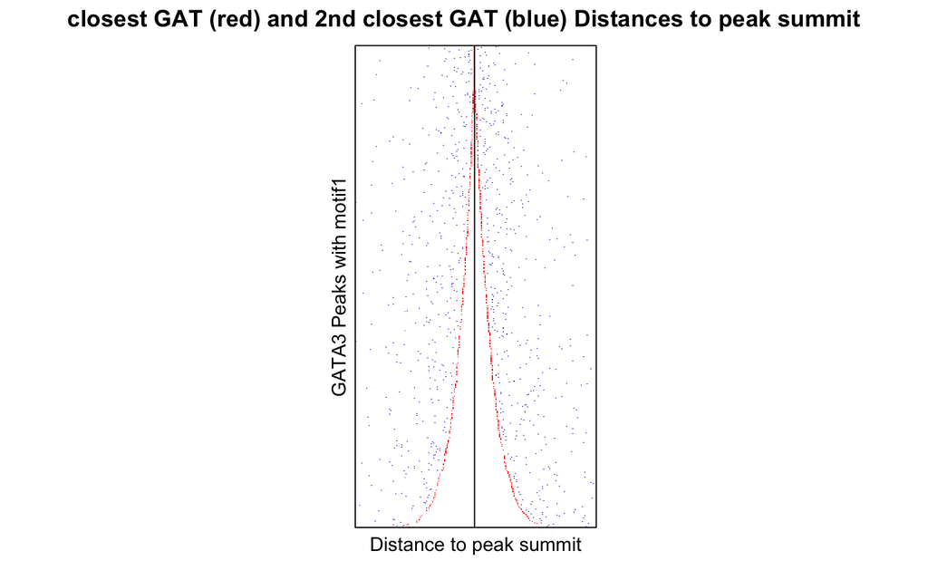

```r
mat_df <- as.data.frame(as.table(mat))
names(mat_df) <- c( "Peak", "Distance", "Value")

# Plot
#pdf("test_heatmap_spaced_GAT_distance_to_peak_summit.pdf")
#print(
levelplot(Value ~ Distance * Peak, data = mat_df,
          col.regions = colorRampPalette(c( "white","blue", "red")),
          aspect=2,
          at = seq(0, 1, length=150),
          axes = FALSE,
          sub="",
          colorkey = FALSE,
          region = TRUE,
          scales = list(draw = FALSE),
          xlab = "Distance to peak summit", ylab = "GATA3 Peaks with motif1", main = "closest GAT (red) and 2nd closest GAT (blue) Distances to peak summit",
          newpage = FALSE,
          panel = function(...) {panel.levelplot(...)
            panel.abline(v=100, col = "black")}
         )
```

```r
#)
#dev.off()
```

Automate analysis:

RSAT:  
Confirm how the software counts the observed spaced 3mer. Will they count twice if seeing 2 spaced 3mer at different locus on one sequence? – yes, see the coherence check section under RSAT.  
Combine results regardless of upstream or downstream orientation.

## 5.3 GATA3 peaks without motifs

### 5.3.1 GAT-GAT/ATC

without_motifs_123456_78_161bp_mast.bed  
37308 peaks.

step1: find the 3mer coordinates (on hg38 genome) that are closest to each peak summit with `closestBed`.  
step2: remove the closest 3mer coordinates from the whole genome 3mer coordinates on the same strand with `bedtools subtract`.  
step3: find the second closest 3mer relative to the closest one.

My list of 3mer: GAT, ATC.

#### 5.3.1.1 STEP1:

240218_closestBed.R:

(cd /home/FCAM/ssun/GATA3_ChIP_PRO_July2023/ChIP_final/GAT_3mer_analaysis/peak_161_without_motifs_12345678/GAT_ATC_240218)

```r
#!/usr/bin/env Rscript

Args=commandArgs(TRUE)
# closestBed function
bedTools.closest <- function(functionstring="/home/FCAM/ssun/packages/bedtools2/bin/closestBed",bed1,bed2,opt.string="") {

  options(scipen =99) # not use scientific notation when writing out

  #write bed formatted data.frames to tempfile
  write.table(bed1,file= 'a.file.bed', quote=F,sep="\t",col.names=F,row.names=F)
  write.table(bed2,file= 'b.file.bed', quote=F,sep="\t",col.names=F,row.names=F)

  # create the command string and call the command using system()
  # the command sort a and b file by coordinates
  command1=paste('sort -k1,1 -k2,2n', 'a.file.bed', '> a.file.sorted.bed')
  cat(command1,"\n") #sort -k1,1 -k2,2n a.file.bed > a.file.sorted.bed
  try(system(command1))
  command2=paste('sort -k1,1 -k2,2n', 'b.file.bed', '> b.file.sorted.bed')
  cat(command2,"\n")
  try(system(command2))

  # the command call closestBed on bed1 and bed2
  command=paste(functionstring, opt.string,"-a",'a.file.sorted.bed',"-b",'b.file.sorted.bed',">",'out.file.bed',sep=" ")
  cat(command,"\n")
  try(system(command))

  res=read.table('out.file.bed',header=F, comment.char='')

  # remove intermediate files
  command3=paste('rm', 'a.file.bed', 'b.file.bed', 'a.file.sorted.bed', 'b.file.sorted.bed', 'out.file.bed')
  cat(command3,"\n")
  try(system(command3))

  colnames(res) = c(colnames(bed1), colnames(bed2), 'dis' )
  return(res)
}

dir1="/labs/Guertin/siyu/Sathyan_GATA3_ChIP_pool1_pool2/overrep_3mer/hg38_full_kmer3_rs1000/seqdump/"
dir2="/home/FCAM/ssun/GATA3_ChIP_PRO_July2023/ChIP_final/GAT_3mer_analaysis/peak_161_without_motifs_12345678/"
dir3="/home/FCAM/ssun/GATA3_ChIP_PRO_July2023/ChIP_final/GAT_3mer_analaysis/ENCODE_DHS_GSE29692/"

prioritized_triplets = c("GAT", "ATC")
library(bigWig)

for (triplet in prioritized_triplets){
  print(triplet)
  # 3mer genome coordinates
  plus.triplet.file=read.table(file = Sys.glob(file.path(paste0(dir1,"hg38.3.3.3plus.*_",triplet, ".bed"))), sep="\t", header=FALSE)
  minus.triplet.file=read.table(file = Sys.glob(file.path(paste0(dir1,"hg38.3.3.3minus.*_",triplet ,".bed"))), sep="\t", header=FALSE)

    # peak summits
    GATA3_peak_summits=center.bed(read.table(paste0(dir2, "without_motifs_123456_78_161bp_mast.bed"), header=FALSE), upstreamWindow = 0, downstreamWindow = 0)
    # consensus neg
    indep.DHS.control.consensus=center.bed(read.table(paste0(dir3, "MCF7DHS_consensus_noGATA_without_motifs_123456_78.bed"), header=FALSE), upstreamWindow = 0, downstreamWindow = 0)

    # closestBed--1st closest plus

    ##
    closest.1st.plus.triplet.to.peak=bedTools.closest(bed1 = GATA3_peak_summits[,1:3], bed2 = plus.triplet.file, opt.string = '-d -t first')
    write.table(closest.1st.plus.triplet.to.peak,file= paste0('closest.1st.plus.',triplet,'.to.GATA3_without_motifs_123456_78_161bp_mast.bed'), quote=F,sep="\t",col.names=F,row.names=F)

    ##
    closest.1st.plus.triplet.to.indep.DHS.control.consensus=bedTools.closest(bed1 = indep.DHS.control.consensus[,1:3], bed2 = plus.triplet.file, opt.string = '-d -t first')
    write.table(closest.1st.plus.triplet.to.indep.DHS.control.consensus,file= paste0('closest.1st.plus.',triplet,'.to.indep.DHS.control.consensus.bed'), quote=F,sep="\t",col.names=F,row.names=F)

     # closestBed--1st closest minus

     ##
     closest.1st.minus.triplet.to.peak=bedTools.closest(bed1 = GATA3_peak_summits[,1:3], bed2 =minus.triplet.file, opt.string = '-d -t first')
     write.table(closest.1st.minus.triplet.to.peak,file= paste0('closest.1st.minus.',triplet,'.to.GATA3_without_motifs_123456_78_161bp_mast.bed'), quote=F,sep="\t",col.names=F,row.names=F)

     ##
     closest.1st.minus.triplet.to.indep.DHS.control.consensus=bedTools.closest(bed1 = indep.DHS.control.consensus[,1:3], bed2 = minus.triplet.file, opt.string = '-d -t first')
    write.table(closest.1st.minus.triplet.to.indep.DHS.control.consensus,file= paste0('closest.1st.minus.',triplet,'.to.indep.DHS.control.consensus.bed'), quote=F,sep="\t",col.names=F,row.names=F)


}
```

runR.sh

```bash
#!/bin/bash
#SBATCH --job-name=runR.sh     # name for job
#SBATCH -N 1
#SBATCH -n 1
#SBATCH -c 8
#SBATCH -p general
#SBATCH --qos=general
#SBATCH --mem=200G
#SBATCH --mail-type=ALL
#SBATCH --mail-user=ssun@uchc.edu
#SBATCH -o runR.sh_%j.out
#SBATCH -e runR.sh_%j.err

module load R/4.1.2
Rscript 240218_closestBed.R
```

#### 5.3.1.2 STEP2: remove the closest 3mer coordinates from the whole genome 3mer coordinates on the same strand with `bedtools subtract`.

```bash
#!/bin/bash
#SBATCH --job-name=remove_1st_3mer.sh     # name for job
#SBATCH -N 1
#SBATCH -n 1
#SBATCH -c 16
#SBATCH -p general
#SBATCH --qos=general
#SBATCH --mem=200G
#SBATCH --mail-type=ALL
#SBATCH --mail-user=ssun@uchc.edu
#SBATCH -o remove_1st_3mer.sh_%j.out
#SBATCH -e remove_1st_3mer.sh_%j.err


input_dir1=/labs/Guertin/siyu/Sathyan_GATA3_ChIP_pool1_pool2/overrep_3mer/hg38_full_kmer3_rs1000/seqdump/
input_dir2=/home/FCAM/ssun/GATA3_ChIP_PRO_July2023/ChIP_final/GAT_3mer_analaysis/peak_161_without_motifs_12345678/GAT_ATC_240218/


prioritized_triplets=("GAT" "ATC")

# Use a for loop to iterate over the
module load bedtools
for triplet in "${prioritized_triplets[@]}"
do
  echo $triplet

    # plus
    sort -k1,1 -k2,2n ${input_dir1}hg38.3.3.3plus*${triplet}.bed > hg38.3.3.3plus.${triplet}.sorted.bed
    awk '{print $4, $5, $6, $7, $8, $9, $10}' ${input_dir2}closest.1st.plus.${triplet}.to.GATA3_without_motifs_123456_78_161bp_mast.bed  | awk '{$1=$1}1' OFS="\t" | uniq | sort -k1,1 -k2,2n > closest.1st.plus.${triplet}.to.GATA3_without_motifs_123456_78_161bp_mast.uniq.sorted.bed
    bedtools subtract -a hg38.3.3.3plus.${triplet}.sorted.bed -b closest.1st.plus.${triplet}.to.GATA3_without_motifs_123456_78_161bp_mast.uniq.sorted.bed -f 1.00 -s > hg38.3.3.3plus.${triplet}_without_1st_plus_${triplet}_to_GATA3_without_motifs_123456_78_161bp_mast.bed
    rm hg38.3.3.3plus.${triplet}.sorted.bed
    rm closest.1st.plus.${triplet}.to.GATA3_without_motifs_123456_78_161bp_mast.uniq.sorted.bed

    # minus
    sort -k1,1 -k2,2n ${input_dir1}hg38.3.3.3minus*${triplet}.bed > hg38.3.3.3minus.${triplet}.sorted.bed
    awk '{print $4, $5, $6, $7, $8, $9, $10}' ${input_dir2}closest.1st.minus.${triplet}.to.GATA3_without_motifs_123456_78_161bp_mast.bed  | awk '{$1=$1}1' OFS="\t" | uniq | sort -k1,1 -k2,2n > closest.1st.minus.${triplet}.to.GATA3_without_motifs_123456_78_161bp_mast.uniq.sorted.bed
    bedtools subtract -a hg38.3.3.3minus.${triplet}.sorted.bed -b closest.1st.minus.${triplet}.to.GATA3_without_motifs_123456_78_161bp_mast.uniq.sorted.bed -f 1.00 -s > hg38.3.3.3minus.${triplet}_without_1st_minus_${triplet}_to_GATA3_without_motifs_123456_78_161bp_mast.bed
    rm hg38.3.3.3minus.${triplet}.sorted.bed
    rm closest.1st.minus.${triplet}.to.GATA3_without_motifs_123456_78_161bp_mast.uniq.sorted.bed

done

# independent DHS control
for triplet in "${prioritized_triplets[@]}"
do
  echo $triplet
  # plus
  sort -k1,1 -k2,2n ${input_dir1}hg38.3.3.3plus*${triplet}.bed > hg38.3.3.3plus.${triplet}.sorted.bed
  awk '{print $4, $5, $6, $7, $8, $9, $10}' ${input_dir2}closest.1st.plus.${triplet}.to.indep.DHS.control.consensus.bed | awk '{$1=$1}1' OFS="\t" | uniq | sort -k1,1 -k2,2n > closest.1st.plus.${triplet}.to.indep.DHS.control.consensus.uniq.sorted.bed
  bedtools subtract -a hg38.3.3.3plus.${triplet}.sorted.bed -b closest.1st.plus.${triplet}.to.indep.DHS.control.consensus.uniq.sorted.bed -f 1.00 -s > hg38.3.3.3plus.36_${triplet}_without_1st_plus_${triplet}_to_indep_DHS_control.bed
   rm hg38.3.3.3plus.${triplet}.sorted.bed
   rm closest.1st.plus.${triplet}.to.indep.DHS.control.consensus.uniq.sorted.bed

  # minus
  sort -k1,1 -k2,2n ${input_dir1}hg38.3.3.3minus*${triplet}.bed > hg38.3.3.3minus.${triplet}.sorted.bed
  awk '{print $4, $5, $6, $7, $8, $9, $10}' ${input_dir2}closest.1st.minus.${triplet}.to.indep.DHS.control.consensus.bed | awk '{$1=$1}1' OFS="\t" | uniq | sort -k1,1 -k2,2n > closest.1st.minus.${triplet}.to.indep.DHS.control.consensus.uniq.sorted.bed
  bedtools subtract -a hg38.3.3.3minus.${triplet}.sorted.bed -b closest.1st.minus.${triplet}.to.indep.DHS.control.consensus.uniq.sorted.bed -f 1.00 -s > hg38.3.3.3minus.36_${triplet}_without_1st_minus_${triplet}_to_indep_DHS_control.bed
   rm hg38.3.3.3minus.${triplet}.sorted.bed
   rm closest.1st.minus.${triplet}.to.indep.DHS.control.consensus.uniq.sorted.bed
done
```

#### 5.3.1.3 STEP3

240218_closestBed2.R

```r
#!/usr/bin/env Rscript

Args=commandArgs(TRUE)

bedTools.closest <- function(functionstring="/home/FCAM/ssun/packages/bedtools2/bin/closestBed",bed1,bed2,opt.string="") {

  options(scipen =99) # not use scientific notation when writing out

  #write bed formatted data.frames to tempfile
  write.table(bed1,file= 'a.file.bed', quote=F,sep="\t",col.names=F,row.names=F)
  write.table(bed2,file= 'b.file.bed', quote=F,sep="\t",col.names=F,row.names=F)

  # create the command string and call the command using system()
  # the command sort a and b file by coordinates
  command1=paste('sort -k1,1 -k2,2n', 'a.file.bed', '> a.file.sorted.bed')
  cat(command1,"\n") #sort -k1,1 -k2,2n a.file.bed > a.file.sorted.bed
  try(system(command1))
  command2=paste('sort -k1,1 -k2,2n', 'b.file.bed', '> b.file.sorted.bed')
  cat(command2,"\n")
  try(system(command2))

  # the command call closestBed on bed1 and bed2
  command=paste(functionstring, opt.string,"-a",'a.file.sorted.bed',"-b",'b.file.sorted.bed',">",'out.file.bed',sep=" ")
  cat(command,"\n")
  try(system(command))

  res=read.table('out.file.bed',header=F, comment.char='')

  # remove intermediate files
  command3=paste('rm', 'a.file.bed', 'b.file.bed', 'a.file.sorted.bed', 'b.file.sorted.bed', 'out.file.bed')
  cat(command3,"\n")
  try(system(command3))

  colnames(res) = c(colnames(bed1), colnames(bed2), 'dis' )
  return(res)
}


#library(lattice)
#library(latticeExtra)
#library(Biostrings)
library(bigWig)

# List of prioritized triplets
prioritized_triplets <- c("GAT", "ATC")

# List to store non-redundant 6mers
all_6mers <- list()
for (i in 1:length(prioritized_triplets)) {
  for (j in 1:length(prioritized_triplets)) {
    pair <- c(prioritized_triplets[i], prioritized_triplets[j])
    # Combine triplets to form a 6mer
    sixmer <- paste(pair, collapse = "")
    all_6mers <- c(all_6mers, list(sixmer))

  }
}

# Create data frame with first 3 bases and last 3 bases
first_3_bases <- substr(all_6mers, 1, 3)
last_3_bases <- substr(all_6mers, 4, 6)
df <- data.frame(First_3_bases = first_3_bases, Last_3_bases = last_3_bases)


# nested loop

dir="/home/FCAM/ssun/GATA3_ChIP_PRO_July2023/ChIP_final/GAT_3mer_analaysis/peak_161_without_motifs_12345678/GAT_ATC_240218/"

win=read.csv(paste0('/home/FCAM/ssun/GATA3_ChIP_PRO_July2023/ChIP_final/GAT_3mer_analaysis/closest_other_3mer/closest_2nd_other_3mer/pattern_anchor_at_GorC_for_bigWig_pkg.csv'))

# GATA3 peaks with motif1,2,4,5,6
  for (i in 1:nrow(df)){
    pattern1=df[i,1]
    pattern2=df[i,2]
    # anchor position: closest +/- pattern1 relative to G/C
    print(pattern1)
    closest_plus_3mer_to_GATA3_peak_summits=fiveprime.bed(read.table(paste0(dir, "closest.1st.plus.", pattern1, ".to.GATA3_without_motifs_123456_78_161bp_mast.bed"), header=FALSE)[,4:11], upstreamWindow = win[win$pattern==pattern1, "plus_upstream"] , downstreamWindow = win[win$pattern==pattern1, "plus_downstream"])

    # query 3mer coordinates on genome (without the overlapped closest 3mer coordinates) - relative to G/C
    print(pattern2)
    plus.3mer.file=fiveprime.bed(read.table(file = paste0(dir, "hg38.3.3.3plus.", pattern2, "_without_1st_plus_", pattern2, "_to_GATA3_without_motifs_123456_78_161bp_mast.bed"), sep="\t", header=FALSE), upstreamWindow = win[win$pattern==pattern2, "plus_upstream"] , downstreamWindow = win[win$pattern==pattern2, "plus_downstream"])

  # 2nd closest plus 3mer to closest plus 3mer
  closest.2nd.plus.3mer.to.1st.plus.3mer.GATA3.without.motif=bedTools.closest(bed1 = closest_plus_3mer_to_GATA3_peak_summits[,1:3], bed2 = plus.3mer.file, opt.string = '-d -t first')


  write.table(closest.2nd.plus.3mer.to.1st.plus.3mer.GATA3.without.motif, file= paste0("closest.2nd.plus.", pattern2, ".to.1st.plus.", pattern1, ".GATA3_without_motifs_123456_78_161bp_mast.bed"), quote=F,sep="\t",col.names=F,row.names=F)
  }


# DHS regions
for (i in 1:nrow(df)){
    pattern1=df[i,1]
    pattern2=df[i,2]
    # anchor position: closest +/- pattern1 relative to G/C
    print(pattern1)
    closest_plus_3mer_to_DHS=fiveprime.bed(read.table(paste0(dir, "closest.1st.plus.", pattern1, ".to.indep.DHS.control.consensus.bed"), header=FALSE)[,4:11], upstreamWindow = win[win$pattern==pattern1, "plus_upstream"] , downstreamWindow = win[win$pattern==pattern1, "plus_downstream"])

    # query 3mer coordinates on genome (without the overlapped closest 3mer coordinates) - relative to G/C
    print(pattern2)
    plus.3mer.file=fiveprime.bed(read.table(file = paste0(dir, "hg38.3.3.3plus.36_", pattern2, "_without_1st_plus_", pattern2, "_to_indep_DHS_control.bed"), sep="\t", header=FALSE), upstreamWindow = win[win$pattern==pattern2, "plus_upstream"] , downstreamWindow = win[win$pattern==pattern2, "plus_downstream"])

  # 2nd closest plus 3mer to closest plus 3mer
  closest.2nd.plus.3mer.to.1st.plus.3mer.DHS=bedTools.closest(bed1 = closest_plus_3mer_to_DHS[,1:3], bed2 = plus.3mer.file, opt.string = '-d -t first')


  write.table(closest.2nd.plus.3mer.to.1st.plus.3mer.DHS, file= paste0("closest.2nd.plus.", pattern2, ".to.1st.plus.", pattern1, ".indep.DHS.control.bed"), quote=F,sep="\t",col.names=F,row.names=F)
  }
```

runR.sh

```bash
#!/bin/bash
#SBATCH --job-name=runR.sh     # name for job
#SBATCH -N 1
#SBATCH -n 1
#SBATCH -c 16
#SBATCH -p general
#SBATCH --qos=general
#SBATCH --mem=200G
#SBATCH --mail-type=ALL
#SBATCH --mail-user=ssun@uchc.edu
#SBATCH -o runR.sh_%j.out
#SBATCH -e runR.sh_%j.err

module load R/4.1.2
Rscript 240218_closestBed2.R
```

**coherence check**

```bash
wc -l closest.2nd.plus.ATC.to.1st.plus.ATC.GATA3_without_motifs_123456_78_161bp_mast.bed
#37308 closest.2nd.plus.ATC.to.1st.plus.ATC.GATA3_without_motifs_123456_78_161bp_mast.bed

wc -l ../without_motifs_123456_78_161bp_mast.bed
#37308 ../without_motifs_123456_78_161bp_mast.bed
```

Also randomly selected a few coordinates and checked on UCSC genome browser to check the bases.

#### 5.3.1.4 Plots

```bash
ls closest.2nd*.bed
```

```
## closest.2nd.plus.ATC.to.1st.plus.ATC.GATA3.without.motifs.quantile1.bed
## closest.2nd.plus.ATC.to.1st.plus.ATC.GATA3_without_motifs_123456_78_161bp_mast.bed
## closest.2nd.plus.ATC.to.1st.plus.ATC.indep.DHS.control.bed
## closest.2nd.plus.ATC.to.1st.plus.GAT.GATA3.without.motifs.quantile1.bed
## closest.2nd.plus.ATC.to.1st.plus.GAT.GATA3_without_motifs_123456_78_161bp_mast.bed
## closest.2nd.plus.ATC.to.1st.plus.GAT.indep.DHS.control.bed
## closest.2nd.plus.GAT.to.1st.plus.ATC.GATA3.without.motifs.quantile1.bed
## closest.2nd.plus.GAT.to.1st.plus.ATC.GATA3_without_motifs_123456_78_161bp_mast.bed
## closest.2nd.plus.GAT.to.1st.plus.ATC.indep.DHS.control.bed
## closest.2nd.plus.GAT.to.1st.plus.GAT.GATA3.without.motifs.quantile1.bed
## closest.2nd.plus.GAT.to.1st.plus.GAT.GATA3_without_motifs_123456_78_161bp_mast.bed
## closest.2nd.plus.GAT.to.1st.plus.GAT.indep.DHS.control.bed
```

**density plot**  
**xy plot**

GATA3 peaks without motifs:

```r
calculate_actual_frequency <- function(data) {
  # Use table() to create a frequency table
  actual_frequencies <- table(data)/length(data)
  result <- data.frame(value = names(actual_frequencies), actual_freq = as.vector(actual_frequencies))
  return(result)
}


df.peak.nomotif = data.frame(matrix(nrow = 0, ncol = 5))
colnames(df.peak.nomotif) = c("dis","anchor_3mer", "query_3mer","abs.dis", "actual_freq")
for (closest_2nd_dis in Sys.glob(file.path("./closest.2nd.plus*.to.1st.plus.*.GATA3_without_motifs_123456_78_161bp_mast.bed"))) {
    print(closest_2nd_dis)
    anchor_3mer =strsplit((strsplit(strsplit(closest_2nd_dis, "/")[[1]][length(strsplit(closest_2nd_dis, "/")[[1]])], 'closest.2nd.plus.*.to.1st.plus.')[[1]][2]), ".GATA3_without_motifs_123456_78_161bp_mast.bed")[[1]][1]
    print(anchor_3mer)
    query_3mer =strsplit((strsplit(strsplit(closest_2nd_dis, "/")[[1]][length(strsplit(closest_2nd_dis, "/")[[1]])], 'closest.2nd.plus.')[[1]][2]), ".to.1st.plus.*.GATA3_without_motifs_123456_78_161bp_mast.bed")[[1]][1]
    print(query_3mer)
    temp = as.data.frame(cbind(read.table(closest_2nd_dis, header=F, comment.char='')[,11], anchor_3mer, query_3mer))
    colnames(temp) = c("dis", "anchor_3mer", "query_3mer")
    temp$dis=as.integer(temp$dis)
    temp$abs.dis=abs(temp$dis)
    actual_frequencies = calculate_actual_frequency(temp$abs.dis)
    temp1= merge(temp, actual_frequencies, by.x = "abs.dis", by.y = "value", all.x = TRUE)
    df.peak.nomotif = rbind(df.peak.nomotif,temp1)
}
```

```
## [1] "./closest.2nd.plus.ATC.to.1st.plus.ATC.GATA3_without_motifs_123456_78_161bp_mast.bed"
## [1] "ATC"
## [1] "ATC"
## [1] "./closest.2nd.plus.ATC.to.1st.plus.GAT.GATA3_without_motifs_123456_78_161bp_mast.bed"
## [1] "GAT"
## [1] "ATC"
## [1] "./closest.2nd.plus.GAT.to.1st.plus.ATC.GATA3_without_motifs_123456_78_161bp_mast.bed"
## [1] "ATC"
## [1] "GAT"
## [1] "./closest.2nd.plus.GAT.to.1st.plus.GAT.GATA3_without_motifs_123456_78_161bp_mast.bed"
## [1] "GAT"
## [1] "GAT"
```

```r
str(df.peak.nomotif)
```

```
## 'data.frame':    149232 obs. of  5 variables:
##  $ abs.dis    : int  3 3 3 3 3 3 3 3 3 3 ...
##  $ dis        : int  3 3 3 3 3 3 3 3 3 3 ...
##  $ anchor_3mer: chr  "ATC" "ATC" "ATC" "ATC" ...
##  $ query_3mer : chr  "ATC" "ATC" "ATC" "ATC" ...
##  $ actual_freq: num  0.0143 0.0143 0.0143 0.0143 0.0143 ...
```

```r
unique(df.peak.nomotif$anchor_3mer)
```

```
## [1] "ATC" "GAT"
```

```r
unique(df.peak.nomotif$query_3mer)
```

```
## [1] "ATC" "GAT"
```

```r
nrow(df.peak.nomotif)
```

```
## [1] 149232
```

```r
head(df.peak.nomotif)
```

```
##   abs.dis dis anchor_3mer query_3mer actual_freq
## 1       3   3         ATC        ATC  0.01434009
## 2       3   3         ATC        ATC  0.01434009
## 3       3   3         ATC        ATC  0.01434009
## 4       3   3         ATC        ATC  0.01434009
## 5       3   3         ATC        ATC  0.01434009
## 6       3   3         ATC        ATC  0.01434009
```

```r
df.peak.nomotif$status="GATA3_peak_without_motifs"
```

DHS regions (neg ctrl):

```r
df.ctrl = data.frame(matrix(nrow = 0, ncol = 5))
colnames(df.ctrl) = c("dis","anchor_3mer", "query_3mer","abs.dis", "actual_freq")
for (closest_2nd_dis in Sys.glob(file.path("./closest.2nd.plus*.to.1st.plus.*.indep.DHS.control.bed"))) {
    print(closest_2nd_dis)
    anchor_3mer =strsplit((strsplit(strsplit(closest_2nd_dis, "/")[[1]][length(strsplit(closest_2nd_dis, "/")[[1]])], 'closest.2nd.plus.*.to.1st.plus.')[[1]][2]), ".indep.DHS.control.bed")[[1]][1]
    print(anchor_3mer)
    query_3mer =strsplit((strsplit(strsplit(closest_2nd_dis, "/")[[1]][length(strsplit(closest_2nd_dis, "/")[[1]])], 'closest.2nd.plus.')[[1]][2]), ".to.1st.plus.*.indep.DHS.control.bed")[[1]][1]
    print(query_3mer)
    temp = as.data.frame(cbind(read.table(closest_2nd_dis, header=F, comment.char='')[,11], anchor_3mer, query_3mer))
    colnames(temp) = c("dis", "anchor_3mer", "query_3mer")
    temp$dis=as.integer(temp$dis)
    temp$abs.dis=abs(temp$dis)
    actual_frequencies = calculate_actual_frequency(temp$abs.dis)
    temp1= merge(temp, actual_frequencies, by.x = "abs.dis", by.y = "value", all.x = TRUE)
    df.ctrl = rbind(df.ctrl,temp1)
}
```

```
## [1] "./closest.2nd.plus.ATC.to.1st.plus.ATC.indep.DHS.control.bed"
## [1] "ATC"
## [1] "ATC"
## [1] "./closest.2nd.plus.ATC.to.1st.plus.GAT.indep.DHS.control.bed"
## [1] "GAT"
## [1] "ATC"
## [1] "./closest.2nd.plus.GAT.to.1st.plus.ATC.indep.DHS.control.bed"
## [1] "ATC"
## [1] "GAT"
## [1] "./closest.2nd.plus.GAT.to.1st.plus.GAT.indep.DHS.control.bed"
## [1] "GAT"
## [1] "GAT"
```

```r
str(df.ctrl)
```

```
## 'data.frame':    231624 obs. of  5 variables:
##  $ abs.dis    : int  3 3 3 3 3 3 3 3 3 3 ...
##  $ dis        : int  3 3 3 3 3 3 3 3 3 3 ...
##  $ anchor_3mer: chr  "ATC" "ATC" "ATC" "ATC" ...
##  $ query_3mer : chr  "ATC" "ATC" "ATC" "ATC" ...
##  $ actual_freq: num  0.0162 0.0162 0.0162 0.0162 0.0162 ...
```

```r
unique(df.ctrl$anchor_3mer)
```

```
## [1] "ATC" "GAT"
```

```r
unique(df.ctrl$query_3mer)
```

```
## [1] "ATC" "GAT"
```

```r
nrow(df.ctrl)
```

```
## [1] 231624
```

```r
head(df.ctrl)
```

```
##   abs.dis dis anchor_3mer query_3mer actual_freq
## 1       3   3         ATC        ATC  0.01619867
## 2       3   3         ATC        ATC  0.01619867
## 3       3   3         ATC        ATC  0.01619867
## 4       3   3         ATC        ATC  0.01619867
## 5       3   3         ATC        ATC  0.01619867
## 6       3   3         ATC        ATC  0.01619867
```

```r
df.ctrl$status="MCF7_DHS_regions"
```

```r
df.plot=rbind(df.peak.nomotif, df.ctrl)
df.plot$pattern = paste0(df.plot$anchor_3mer, "-", df.plot$query_3mer)

df.plot$pattern = factor(df.plot$pattern, levels = c("ATC-ATC", "GAT-ATC", "ATC-GAT", "GAT-GAT"))
df.plot$status = factor(df.plot$status, levels = c("GATA3_peak_without_motifs", "MCF7_DHS_regions"))

nrow(df.plot)
```

```
## [1] 380856
```

```r
nrow(df.plot[!duplicated(df.plot), ])
```

```
## [1] 4993
```

```r
summary(df.plot[!duplicated(df.plot), ])
```

```
##     abs.dis             dis          anchor_3mer         query_3mer
##  Min.   :    1.0   Min.   :    1.0   Length:4993        Length:4993
##  1st Qu.:  158.0   1st Qu.:  158.0   Class :character   Class :character
##  Median :  314.0   Median :  314.0   Mode  :character   Mode  :character
##  Mean   :  341.1   Mean   :  341.1
##  3rd Qu.:  473.0   3rd Qu.:  473.0
##  Max.   :17669.0   Max.   :17669.0
##   actual_freq                              status        pattern
##  Min.   :1.727e-05   GATA3_peak_without_motifs:2610   ATC-ATC:1216
##  1st Qu.:5.361e-05   MCF7_DHS_regions         :2383   GAT-ATC:1321
##  Median :2.763e-04                                    ATC-GAT:1280
##  Mean   :1.602e-03                                    GAT-GAT:1176
##  3rd Qu.:1.831e-03
##  Max.   :1.161e-01
```

```r
library(lattice)
library(latticeExtra)
pdf('xy_closest_2nd_3mer_to_closest_1st_3mer_to_GATA3_peaks_without_motifs.pdf', width=15,height=5)
print(
  xyplot(actual_freq ~ abs.dis | pattern,
         #data = df.plot[!duplicated(df.plot), ],
         data = df.plot,
         groups = status,
         auto.key = list(space = "right", lines=TRUE, points=FALSE, cex = 1),
         aspect = 1,
         xlim=c(0,50),
         ylim=c(0, 0.15),
         layout=c(4,1),
         #type = c('p', 'smooth'),
         xlab = "relative distance (bp) between zinc finger (anchor at G/C)",
         ylab="Frequency",
         #main="Independent DHS Regions",
         between=list(y=1.0),
         scales = list(x = list(relation="free", rot = 45, at = seq(from = 0, to = 50, by = 5))),
         par.settings = list(superpose.line = list(col=c("red", "black"), lwd=2), strip.background=list(col="grey85")),
         panel = function(x,y,...) {panel.abline(v=c(seq(1, 10, 1)), col = "grey90")
                                    panel.densityplot(x, data = df.plot,
                                                        from=0,
                                                        to=50,
                                                        lty = c(1),
                                                        lwd=2,
                                                        darg=list(bw = "nrd0", kernel="gaussian"),
                                                        type = "count",
                                                        col=c("pink","grey"), ...)
                                    panel.xyplot(x, y,
                                                   col=c("red","black"),
                                                   pch=18,
                                                   cex=0.6,...)


  })
)
dev.off()
```

We can also demonstrate the relative enrichment by subtracting the actual frequency of GATA3 peaks from that of the DHS regions at each relative distance.

```r
# GATA3 peaks
uniq.df.peak.nomotif=df.peak.nomotif[!duplicated(df.peak.nomotif), 1:5]

#DHS regions
uniq.df.ctrl=df.ctrl[!duplicated(df.ctrl), 1:5]
colnames(uniq.df.ctrl)[5]="actual_freq_DHS"

#calculate the relative frequency
  #by subtraction of actual frequency between GATA3 peaks and DHS regions
df.plot2=merge(uniq.df.peak.nomotif, uniq.df.ctrl, by=c("abs.dis", "dis", "anchor_3mer", "query_3mer"), all.x = TRUE)
df.plot2$rel_freq <- ifelse(is.na(df.plot2$actual_freq_DHS), NA, df.plot2$actual_freq - df.plot2$actual_freq_DHS)
df.plot2$pattern = paste0(df.plot2$anchor_3mer, "-", df.plot2$query_3mer)

df.plot2$pattern = factor(df.plot2$pattern, levels = c("ATC-ATC", "GAT-ATC", "ATC-GAT", "GAT-GAT"))

library(lattice)
library(latticeExtra)
pdf(paste0('xy_closest_2nd_3mer_to_closest_1st_3mer_to_GATA3_peaks_without_motifs_compare_to_DHS.pdf'), width=15,height=5)
print(xyplot(rel_freq ~ abs.dis | pattern,
         data = df.plot2,
         #groups = pattern,
         #auto.key = list(space = "right", lines=TRUE, points=FALSE, cex = 1),
         aspect = 1,
         xlim=c(0,50),
         ylim=c(0, 0.1),
         layout=c(4,1),
         #type = c('p', 'smooth'),
         xlab = "relative distance (bp) between zinc finger (anchor at G/C)",
         ylab="Relative Frequency (GATA3 peaks - DHS regions)",
         #main=paste0("GATA3 peak with ", motif),
         between=list(y=1.0),
         scales = list(x = list(relation="free", rot = 45, at = seq(from = 0, to = 50, by = 5))),
         #par.settings = list(superpose.line = list(col=c("pink", "skyblue"), lwd=2), strip.background=list(col="grey85")),
         panel = function(x,y,...) {panel.abline(v=c(seq(1, 15, 1)), col = "grey90")
                                    panel.densityplot(x, data = df.plot2,
                                                        from=0,
                                                        to=50,
                                                        lty = c(1),
                                                        lwd=2,
                                                        darg=list(bw = "nrd0", kernel="gaussian"),
                                                        type = "count",
                                                        col="pink", ...)
                                      panel.xyplot(x, y,
                                                   col="red",
                                                   pch=18,
                                                   cex=0.6,...)


  })
)
dev.off()
```

It seems that these peaks have fewer enriched spaced-3mers; however, they could still be enriched by single sites as GATA binding elements.

### 5.3.2 GAT/ATC single site

```bash
ls closest.1st*.bed
head closest.1st.minus.ATC.to.GATA3_without_motifs_123456_78_161bp_mast.bed
wc -l closest.1st.minus.ATC.to.GATA3_without_motifs_123456_78_161bp_mast.bed
wc -l closest.1st.minus.GAT.to.GATA3_without_motifs_123456_78_161bp_mast.bed
```

```
## closest.1st.minus.ATC.to.GATA3_without_motifs_123456_78_161bp_mast.bed
## closest.1st.minus.ATC.to.GATA3_without_motifs_quantile1.bed
## closest.1st.minus.ATC.to.indep.DHS.control.consensus.bed
## closest.1st.minus.GAT.to.GATA3.with.motif_1.bed
## closest.1st.minus.GAT.to.GATA3.with.motif_2.bed
## closest.1st.minus.GAT.to.GATA3.with.motif_4.bed
## closest.1st.minus.GAT.to.GATA3.with.motif_5.bed
## closest.1st.minus.GAT.to.GATA3.with.motif_6.bed
## closest.1st.minus.GAT.to.GATA3_without_motifs_123456_78_161bp_mast.bed
## closest.1st.minus.GAT.to.GATA3_without_motifs_quantile1.bed
## closest.1st.minus.GAT.to.indep.DHS.control.consensus.bed
## closest.1st.plus.ATC.to.GATA3_without_motifs_123456_78_161bp_mast.bed
## closest.1st.plus.ATC.to.GATA3_without_motifs_quantile1.bed
## closest.1st.plus.ATC.to.indep.DHS.control.consensus.bed
## closest.1st.plus.GAT.to.GATA3.with.motif_1.bed
## closest.1st.plus.GAT.to.GATA3.with.motif_2.bed
## closest.1st.plus.GAT.to.GATA3.with.motif_4.bed
## closest.1st.plus.GAT.to.GATA3.with.motif_5.bed
## closest.1st.plus.GAT.to.GATA3.with.motif_6.bed
## closest.1st.plus.GAT.to.GATA3_without_motifs_123456_78_161bp_mast.bed
## closest.1st.plus.GAT.to.GATA3_without_motifs_quantile1.bed
## closest.1st.plus.GAT.to.indep.DHS.control.consensus.bed
## chr1 827380  827381  chr1    827302  827305  36  36  -   ATC 76
## chr1 916769  916770  chr1    916719  916722  36  36  -   ATC 48
## chr1 924853  924854  chr1    924740  924743  36  36  -   ATC 111
## chr1 966653  966654  chr1    966718  966721  36  36  -   ATC 65
## chr1 999508  999509  chr1    999577  999580  36  36  -   ATC 69
## chr1 1000536 1000537 chr1    1000627 1000630 36  36  -   ATC 91
## chr1 1001891 1001892 chr1    1001937 1001940 36  36  -   ATC 46
## chr1 1013265 1013266 chr1    1013247 1013250 36  36  -   ATC 16
## chr1 1013580 1013581 chr1    1013584 1013587 36  36  -   ATC 4
## chr1 1020187 1020188 chr1    1020330 1020333 36  36  -   ATC 143
##    37308 closest.1st.minus.ATC.to.GATA3_without_motifs_123456_78_161bp_mast.bed
##    37308 closest.1st.minus.GAT.to.GATA3_without_motifs_123456_78_161bp_mast.bed
```

**xy plot**

GATA3 peaks without motifs:

```r
calculate_actual_frequency <- function(data) {
  # Use table() to create a frequency table
  actual_frequencies <- table(data)/length(data)
  result <- data.frame(value = names(actual_frequencies), actual_freq = as.vector(actual_frequencies))
  return(result)
}


df.peak.nomotif = data.frame(matrix(nrow = 0, ncol = 5))
colnames(df.peak.nomotif) = c("dis","closest_3mer", "abs.dis", "actual_freq")
for (closest_1st_dis in Sys.glob(file.path("./closest.1st.*.to.GATA3_without_motifs_123456_78_161bp_mast.bed"))) {
    print(closest_1st_dis)
    closest_3mer =strsplit((strsplit(strsplit(closest_1st_dis, "/")[[1]][length(strsplit(closest_1st_dis, "/")[[1]])], 'closest.1st.')[[1]][2]), ".to.GATA3_without_motifs_123456_78_161bp_mast.bed")[[1]][1]
    print(closest_3mer)

    temp = as.data.frame(cbind(read.table(closest_1st_dis, header=F, comment.char='')[,11], closest_3mer))
    colnames(temp) = c("dis", "closest_3mer")
    temp$dis=as.integer(temp$dis)
    temp$abs.dis=abs(temp$dis)
    actual_frequencies = calculate_actual_frequency(temp$abs.dis)
    temp1= merge(temp, actual_frequencies, by.x = "abs.dis", by.y = "value", all.x = TRUE)
    df.peak.nomotif = rbind(df.peak.nomotif,temp1)
}
```

```
## [1] "./closest.1st.minus.ATC.to.GATA3_without_motifs_123456_78_161bp_mast.bed"
## [1] "minus.ATC"
## [1] "./closest.1st.minus.GAT.to.GATA3_without_motifs_123456_78_161bp_mast.bed"
## [1] "minus.GAT"
## [1] "./closest.1st.plus.ATC.to.GATA3_without_motifs_123456_78_161bp_mast.bed"
## [1] "plus.ATC"
## [1] "./closest.1st.plus.GAT.to.GATA3_without_motifs_123456_78_161bp_mast.bed"
## [1] "plus.GAT"
```

```r
str(df.peak.nomotif)
```

```
## 'data.frame':    149232 obs. of  4 variables:
##  $ abs.dis     : int  0 0 0 0 0 0 0 0 0 0 ...
##  $ dis         : int  0 0 0 0 0 0 0 0 0 0 ...
##  $ closest_3mer: chr  "minus.ATC" "minus.ATC" "minus.ATC" "minus.ATC" ...
##  $ actual_freq : num  0.0386 0.0386 0.0386 0.0386 0.0386 ...
```

```r
unique(df.peak.nomotif$closest_3mer)
```

```
## [1] "minus.ATC" "minus.GAT" "plus.ATC"  "plus.GAT"
```

```r
nrow(df.peak.nomotif)
```

```
## [1] 149232
```

```r
head(df.peak.nomotif)
```

```
##   abs.dis dis closest_3mer actual_freq
## 1       0   0    minus.ATC  0.03857082
## 2       0   0    minus.ATC  0.03857082
## 3       0   0    minus.ATC  0.03857082
## 4       0   0    minus.ATC  0.03857082
## 5       0   0    minus.ATC  0.03857082
## 6       0   0    minus.ATC  0.03857082
```

```r
df.peak.nomotif$status="GATA3_peak_without_motifs"
```

DHS regions (neg ctrl):

```r
df.ctrl = data.frame(matrix(nrow = 0, ncol = 5))
colnames(df.ctrl) = c("dis","closest_3mer", "abs.dis", "actual_freq")
for (closest_1st_dis in Sys.glob(file.path("./closest.1st.*.to.indep.DHS.control.consensus.bed"))) {
    print(closest_1st_dis)
    closest_3mer =strsplit((strsplit(strsplit(closest_1st_dis, "/")[[1]][length(strsplit(closest_1st_dis, "/")[[1]])], 'closest.1st.')[[1]][2]), ".to.indep.DHS.control.consensus.bed")[[1]][1]
    print(closest_3mer)

    temp = as.data.frame(cbind(read.table(closest_1st_dis, header=F, comment.char='')[,11], closest_3mer))
    colnames(temp) = c("dis", "closest_3mer")
    temp$dis=as.integer(temp$dis)
    temp$abs.dis=abs(temp$dis)
    actual_frequencies = calculate_actual_frequency(temp$abs.dis)
    temp1= merge(temp, actual_frequencies, by.x = "abs.dis", by.y = "value", all.x = TRUE)
    df.ctrl = rbind(df.ctrl,temp1)
}
```

```
## [1] "./closest.1st.minus.ATC.to.indep.DHS.control.consensus.bed"
## [1] "minus.ATC"
## [1] "./closest.1st.minus.GAT.to.indep.DHS.control.consensus.bed"
## [1] "minus.GAT"
## [1] "./closest.1st.plus.ATC.to.indep.DHS.control.consensus.bed"
## [1] "plus.ATC"
## [1] "./closest.1st.plus.GAT.to.indep.DHS.control.consensus.bed"
## [1] "plus.GAT"
```

```r
str(df.ctrl)
```

```
## 'data.frame':    231624 obs. of  4 variables:
##  $ abs.dis     : int  0 0 0 0 0 0 0 0 0 0 ...
##  $ dis         : int  0 0 0 0 0 0 0 0 0 0 ...
##  $ closest_3mer: chr  "minus.ATC" "minus.ATC" "minus.ATC" "minus.ATC" ...
##  $ actual_freq : num  0.0262 0.0262 0.0262 0.0262 0.0262 ...
```

```r
unique(df.ctrl$closest_3mer)
```

```
## [1] "minus.ATC" "minus.GAT" "plus.ATC"  "plus.GAT"
```

```r
nrow(df.ctrl)
```

```
## [1] 231624
```

```r
head(df.ctrl)
```

```
##   abs.dis dis closest_3mer actual_freq
## 1       0   0    minus.ATC   0.0262149
## 2       0   0    minus.ATC   0.0262149
## 3       0   0    minus.ATC   0.0262149
## 4       0   0    minus.ATC   0.0262149
## 5       0   0    minus.ATC   0.0262149
## 6       0   0    minus.ATC   0.0262149
```

```r
df.ctrl$status="MCF7_DHS_regions"
```

```r
df.plot=rbind(df.peak.nomotif, df.ctrl)

df.plot$closest_3mer = factor(df.plot$closest_3mer, levels = c("plus.GAT", "minus.ATC" , "minus.GAT", "plus.ATC"))
df.plot$status = factor(df.plot$status, levels = c("GATA3_peak_without_motifs", "MCF7_DHS_regions"))

nrow(df.plot)
```

```
## [1] 380856
```

```r
nrow(df.plot[!duplicated(df.plot), ])
```

```
## [1] 8545
```

```r
summary(df.plot[!duplicated(df.plot), ])
```

```
##     abs.dis            dis            closest_3mer   actual_freq
##  Min.   :     0   Min.   :     0   plus.GAT :2124   Min.   :1.727e-05
##  1st Qu.:   267   1st Qu.:   267   minus.ATC:2141   1st Qu.:1.727e-05
##  Median :  1028   Median :  1028   minus.GAT:2151   Median :1.727e-05
##  Mean   : 28226   Mean   : 28226   plus.ATC :2129   Mean   :9.362e-04
##  3rd Qu.: 19605   3rd Qu.: 19605                    3rd Qu.:1.900e-04
##  Max.   :890240   Max.   :890240                    Max.   :3.860e-02
##                        status
##  GATA3_peak_without_motifs:2454
##  MCF7_DHS_regions         :6091
##
##
##
##
```

```r
library(lattice)
library(latticeExtra)
pdf('xy_closest_1st_3mer_to_peaks_without_motifs.pdf', width=15,height=5)
print(
  xyplot(actual_freq ~ abs.dis | closest_3mer,
         #data = df.plot[!duplicated(df.plot), ],
         data = df.plot,
         groups = status,
         auto.key = list(space = "right", lines=TRUE, points=FALSE, cex = 1),
         aspect = 1,
         xlim=c(0,50),
         ylim=c(0, 0.15),
         layout=c(4,1),
         #type = c('p', 'smooth'),
         xlab = "relative distance (bp) between zinc finger (anchor at G/C)",
         ylab="Frequency",
         #main="Independent DHS Regions",
         between=list(y=1.0),
         scales = list(x = list(relation="free", rot = 45, at = seq(from = 0, to = 50, by = 5))),
         par.settings = list(superpose.line = list(col=c("red", "black"), lwd=2), strip.background=list(col="grey85")),
         panel = function(x,y,...) {panel.abline(v=c(seq(1, 10, 1)), col = "grey90")
                                    panel.densityplot(x, data = df.plot,
                                                        from=0,
                                                        to=50,
                                                        lty = c(1),
                                                        lwd=2,
                                                        darg=list(bw = "nrd0", kernel="gaussian"),
                                                        type = "count",
                                                        col=c("pink","grey"), ...)
                                    panel.xyplot(x, y,
                                                   col=c("red","black"),
                                                   pch=18,
                                                   cex=0.6,...)


  })
)
dev.off()
```

Again, we can demonstrate the relative enrichment of closest 3mer by subtracting the actual frequency of GATA3 peaks from that of the DHS regions at each relative distance.

```r
# GATA3 peaks
uniq.df.peak.nomotif=df.peak.nomotif[!duplicated(df.peak.nomotif), 1:4]

#DHS regions
uniq.df.ctrl=df.ctrl[!duplicated(df.ctrl), 1:4]
colnames(uniq.df.ctrl)[4]="actual_freq_DHS"

#calculate the relative frequency
  #by subtraction of actual frequency between GATA3 peaks and DHS regions
df.plot2=merge(uniq.df.peak.nomotif, uniq.df.ctrl, by=c("abs.dis", "dis", "closest_3mer"), all.x = TRUE)
df.plot2$rel_freq <- ifelse(is.na(df.plot2$actual_freq_DHS), NA, df.plot2$actual_freq - df.plot2$actual_freq_DHS)
df.plot2$closest_3mer = factor(df.plot2$closest_3mer, levels = c("plus.GAT", "minus.ATC" , "minus.GAT", "plus.ATC"))


library(lattice)
library(latticeExtra)
pdf(paste0('xy_closest_1st_3mer_GATA3_peaks_without_motifs_compare_to_DHS.pdf'), width=15,height=5)
print(xyplot(rel_freq ~ abs.dis | closest_3mer,
         data = df.plot2,
         #groups = pattern,
         #auto.key = list(space = "right", lines=TRUE, points=FALSE, cex = 1),
         aspect = 1,
         xlim=c(0,50),
         ylim=c(0, 0.1),
         layout=c(4,1),
         #type = c('p', 'smooth'),
         xlab = "relative distance (bp) between zinc finger (anchor at G/C)",
         ylab="Relative Frequency (GATA3 peaks - DHS regions)",
         #main=paste0("GATA3 peak with ", motif),
         between=list(y=1.0),
         scales = list(x = list(relation="free", rot = 45, at = seq(from = 0, to = 50, by = 5))),
         #par.settings = list(superpose.line = list(col=c("pink", "skyblue"), lwd=2), strip.background=list(col="grey85")),
         panel = function(x,y,...) {panel.abline(v=c(seq(0, 15, 1)), col = "grey90")
                                    panel.densityplot(x, data = df.plot2,
                                                        from=0,
                                                        to=50,
                                                        lty = c(1),
                                                        lwd=2,
                                                        darg=list(bw = "nrd0", kernel="gaussian"),
                                                        type = "count",
                                                        col="pink", ...)
                                      panel.xyplot(x, y,
                                                   col="red",
                                                   pch=18,
                                                   cex=0.6,...)


  })
)
dev.off()
```

We can observe the enrichment, but the frequency of this enrichment is low. This could be attributed to some low-intensity peaks that are not bound by GATA3; they were labeled as GATA3 peaks because the MACS3 peak calling software identified peaks based on the p-value we set. These peaks could saturate the enrichment frequency because they increase the denominator when calculating the frequency.

When we divide these GATA3 peaks (without motifs) into five quantiles based on their intensity, it becomes evident that peaks with higher intensity also exhibit stronger enrichment in observing GAT/ATC close to the peak summit.

## 5.4 GATA3 peaks without motifs–quantiles

We have divided the GATA3 peaks without motifs into 5 quantiles based on the ranked intensity in January_updates 3.2.2. We have previously made CDF plots to visualize the enrichment.

quantile0.2_summits.bed  
quantile0.6_summits.bed  
quantile1_summits.bed  
quantile0.4_summits.bed  
quantile0.8_summits.bed

#### 5.4.0.1 STEP1:

240218_closestBed3.R:

(cd /home/FCAM/ssun/GATA3_ChIP_PRO_July2023/ChIP_final/GAT_3mer_analaysis/peak_161_without_motifs_12345678/GAT_ATC_240218/quantiles)

```r
#!/usr/bin/env Rscript

Args=commandArgs(TRUE)
# closestBed function
bedTools.closest <- function(functionstring="/home/FCAM/ssun/packages/bedtools2/bin/closestBed",bed1,bed2,opt.string="") {

  options(scipen =99) # not use scientific notation when writing out

  #write bed formatted data.frames to tempfile
  write.table(bed1,file= 'a.file.bed', quote=F,sep="\t",col.names=F,row.names=F)
  write.table(bed2,file= 'b.file.bed', quote=F,sep="\t",col.names=F,row.names=F)

  # create the command string and call the command using system()
  # the command sort a and b file by coordinates
  command1=paste('sort -k1,1 -k2,2n', 'a.file.bed', '> a.file.sorted.bed')
  cat(command1,"\n") #sort -k1,1 -k2,2n a.file.bed > a.file.sorted.bed
  try(system(command1))
  command2=paste('sort -k1,1 -k2,2n', 'b.file.bed', '> b.file.sorted.bed')
  cat(command2,"\n")
  try(system(command2))

  # the command call closestBed on bed1 and bed2
  command=paste(functionstring, opt.string,"-a",'a.file.sorted.bed',"-b",'b.file.sorted.bed',">",'out.file.bed',sep=" ")
  cat(command,"\n")
  try(system(command))

  res=read.table('out.file.bed',header=F, comment.char='')

  # remove intermediate files
  command3=paste('rm', 'a.file.bed', 'b.file.bed', 'a.file.sorted.bed', 'b.file.sorted.bed', 'out.file.bed')
  cat(command3,"\n")
  try(system(command3))

  colnames(res) = c(colnames(bed1), colnames(bed2), 'dis' )
  return(res)
}

dir1="/labs/Guertin/siyu/Sathyan_GATA3_ChIP_pool1_pool2/overrep_3mer/hg38_full_kmer3_rs1000/seqdump/"
dir2="/home/FCAM/ssun/GATA3_ChIP_PRO_July2023/ChIP_final/GAT_3mer_analaysis/peak_161_without_motifs_12345678/"
#dir3="/home/FCAM/ssun/GATA3_ChIP_PRO_July2023/ChIP_final/GAT_3mer_analaysis/ENCODE_DHS_GSE29692/"

prioritized_triplets = c("GAT", "ATC")
library(bigWig)

quantiles = c("quantile1", "quantile0.8","quantile0.6","quantile0.4","quantile0.2")

  for (triplet in prioritized_triplets){
  print(triplet)
  # 3mer genome coordinates
  plus.triplet.file=read.table(file = Sys.glob(file.path(paste0(dir1,"hg38.3.3.3plus.*_",triplet, ".bed"))), sep="\t", header=FALSE)
  minus.triplet.file=read.table(file = Sys.glob(file.path(paste0(dir1,"hg38.3.3.3minus.*_",triplet ,".bed"))), sep="\t", header=FALSE)

  for (quantile in quantiles) {
    print(quantile)
    # peak summits
    GATA3_peak_summits=center.bed(read.table(paste0(dir2, quantile, "_summits.bed"), header=FALSE), upstreamWindow = 0, downstreamWindow = 0)

    # closestBed--1st closest plus
    closest.1st.plus.triplet.to.peak=bedTools.closest(bed1 = GATA3_peak_summits[,1:3], bed2 = plus.triplet.file, opt.string = '-d -t first')
    write.table(closest.1st.plus.triplet.to.peak,file= paste0('closest.1st.plus.',triplet,'.to.GATA3_without_motifs_', quantile, '.bed'), quote=F,sep="\t",col.names=F,row.names=F)

     # closestBed--1st closest minus
     closest.1st.minus.triplet.to.peak=bedTools.closest(bed1 = GATA3_peak_summits[,1:3], bed2 =minus.triplet.file, opt.string = '-d -t first')
     write.table(closest.1st.minus.triplet.to.peak,file= paste0('closest.1st.minus.',triplet,'.to.GATA3_without_motifs_', quantile, '.bed'), quote=F,sep="\t",col.names=F,row.names=F)

  }
}
```

runR.sh

```bash
#!/bin/bash
#SBATCH --job-name=runR.sh     # name for job
#SBATCH -N 1
#SBATCH -n 1
#SBATCH -c 8
#SBATCH -p general
#SBATCH --qos=general
#SBATCH --mem=200G
#SBATCH --mail-type=ALL
#SBATCH --mail-user=ssun@uchc.edu
#SBATCH -o runR.sh_%j.out
#SBATCH -e runR.sh_%j.err

module load R/4.1.2
Rscript 240218_closestBed3.R
```

#### 5.4.0.2 STEP2: remove the closest 3mer coordinates from the whole genome 3mer coordinates on the same strand with `bedtools subtract`.

```bash
#!/bin/bash
#SBATCH --job-name=remove_1st_3mer.sh     # name for job
#SBATCH -N 1
#SBATCH -n 1
#SBATCH -c 16
#SBATCH -p general
#SBATCH --qos=general
#SBATCH --mem=200G
#SBATCH --mail-type=ALL
#SBATCH --mail-user=ssun@uchc.edu
#SBATCH -o remove_1st_3mer.sh_%j.out
#SBATCH -e remove_1st_3mer.sh_%j.err


input_dir1=/labs/Guertin/siyu/Sathyan_GATA3_ChIP_pool1_pool2/overrep_3mer/hg38_full_kmer3_rs1000/seqdump/
input_dir2=/home/FCAM/ssun/GATA3_ChIP_PRO_July2023/ChIP_final/GAT_3mer_analaysis/peak_161_without_motifs_12345678/GAT_ATC_240218/quantiles/


prioritized_triplets=("GAT" "ATC")
quantiles=("quantile1" "quantile0.8" "quantile0.6" "quantile0.4" "quantile0.2")


# Use a for loop to iterate over the list
module load bedtools
for triplet in "${prioritized_triplets[@]}"
do
  echo $triplet

  for quantile in "${quantiles[@]}"
  do
    echo $quantile
    # plus
    sort -k1,1 -k2,2n ${input_dir1}hg38.3.3.3plus*${triplet}.bed > hg38.3.3.3plus.${triplet}.sorted.bed
    awk '{print $4, $5, $6, $7, $8, $9, $10}' ${input_dir2}closest.1st.plus.${triplet}.to.GATA3_without_motifs_${quantile}.bed  | awk '{$1=$1}1' OFS="\t" | uniq | sort -k1,1 -k2,2n > closest.1st.plus.${triplet}.to.GATA3_without_motifs_${quantile}.uniq.sorted.bed
    bedtools subtract -a hg38.3.3.3plus.${triplet}.sorted.bed -b closest.1st.plus.${triplet}.to.GATA3_without_motifs_${quantile}.uniq.sorted.bed -f 1.00 -s > hg38.3.3.3plus.${triplet}_without_1st_plus_${triplet}_to_GATA3_without_motifs_${quantile}.bed
    rm hg38.3.3.3plus.${triplet}.sorted.bed
    rm closest.1st.plus.${triplet}.to.GATA3_without_motifs_${quantile}.uniq.sorted.bed

    # minus
    sort -k1,1 -k2,2n ${input_dir1}hg38.3.3.3minus*${triplet}.bed > hg38.3.3.3minus.${triplet}.sorted.bed
    awk '{print $4, $5, $6, $7, $8, $9, $10}' ${input_dir2}closest.1st.minus.${triplet}.to.GATA3_without_motifs_${quantile}.bed  | awk '{$1=$1}1' OFS="\t" | uniq | sort -k1,1 -k2,2n > closest.1st.minus.${triplet}.to.GATA3_without_motifs_${quantile}.uniq.sorted.bed
    bedtools subtract -a hg38.3.3.3minus.${triplet}.sorted.bed -b closest.1st.minus.${triplet}.to.GATA3_without_motifs_${quantile}.uniq.sorted.bed -f 1.00 -s > hg38.3.3.3minus.${triplet}_without_1st_minus_${triplet}_to_GATA3_without_motifs_${quantile}.bed
    rm hg38.3.3.3minus.${triplet}.sorted.bed
    rm closest.1st.minus.${triplet}.to.GATA3_without_motifs_${quantile}.uniq.sorted.bed
  done
done
```

#### 5.4.0.3 STEP3

240218_closestBed4.R

```r
#!/usr/bin/env Rscript

Args=commandArgs(TRUE)

bedTools.closest <- function(functionstring="/home/FCAM/ssun/packages/bedtools2/bin/closestBed",bed1,bed2,opt.string="") {

  options(scipen =99) # not use scientific notation when writing out

  #write bed formatted data.frames to tempfile
  write.table(bed1,file= 'a.file.bed', quote=F,sep="\t",col.names=F,row.names=F)
  write.table(bed2,file= 'b.file.bed', quote=F,sep="\t",col.names=F,row.names=F)

  # create the command string and call the command using system()
  # the command sort a and b file by coordinates
  command1=paste('sort -k1,1 -k2,2n', 'a.file.bed', '> a.file.sorted.bed')
  cat(command1,"\n") #sort -k1,1 -k2,2n a.file.bed > a.file.sorted.bed
  try(system(command1))
  command2=paste('sort -k1,1 -k2,2n', 'b.file.bed', '> b.file.sorted.bed')
  cat(command2,"\n")
  try(system(command2))

  # the command call closestBed on bed1 and bed2
  command=paste(functionstring, opt.string,"-a",'a.file.sorted.bed',"-b",'b.file.sorted.bed',">",'out.file.bed',sep=" ")
  cat(command,"\n")
  try(system(command))

  res=read.table('out.file.bed',header=F, comment.char='')

  # remove intermediate files
  command3=paste('rm', 'a.file.bed', 'b.file.bed', 'a.file.sorted.bed', 'b.file.sorted.bed', 'out.file.bed')
  cat(command3,"\n")
  try(system(command3))

  colnames(res) = c(colnames(bed1), colnames(bed2), 'dis' )
  return(res)
}


#library(lattice)
#library(latticeExtra)
#library(Biostrings)
library(bigWig)

# List of prioritized triplets
prioritized_triplets <- c("GAT", "ATC")

# List to store non-redundant 6mers
all_6mers <- list()
for (i in 1:length(prioritized_triplets)) {
  for (j in 1:length(prioritized_triplets)) {
    pair <- c(prioritized_triplets[i], prioritized_triplets[j])
    # Combine triplets to form a 6mer
    sixmer <- paste(pair, collapse = "")
    all_6mers <- c(all_6mers, list(sixmer))

  }
}

# Create data frame with first 3 bases and last 3 bases
first_3_bases <- substr(all_6mers, 1, 3)
last_3_bases <- substr(all_6mers, 4, 6)
df <- data.frame(First_3_bases = first_3_bases, Last_3_bases = last_3_bases)


# nested loop
dir="/home/FCAM/ssun/GATA3_ChIP_PRO_July2023/ChIP_final/GAT_3mer_analaysis/peak_161_without_motifs_12345678/GAT_ATC_240218/quantiles/"
quantiles = c("quantile1", "quantile0.8","quantile0.6","quantile0.4","quantile0.2")
win=read.csv(paste0('/home/FCAM/ssun/GATA3_ChIP_PRO_July2023/ChIP_final/GAT_3mer_analaysis/closest_other_3mer/closest_2nd_other_3mer/pattern_anchor_at_GorC_for_bigWig_pkg.csv'))

# GATA3 peaks without motifs
for (quantile in quantiles) {
  print(quantile)
  for (i in 1:nrow(df)){
    pattern1=df[i,1]
    pattern2=df[i,2]
    # anchor position: closest +/- pattern1 relative to G/C
    print(pattern1)
    closest_plus_3mer_to_GATA3_peak_summits=fiveprime.bed(read.table(paste0(dir, "closest.1st.plus.", pattern1, ".to.GATA3_without_motifs_", quantile, ".bed"), header=FALSE)[,4:11], upstreamWindow = win[win$pattern==pattern1, "plus_upstream"] , downstreamWindow = win[win$pattern==pattern1, "plus_downstream"])

    # query 3mer coordinates on genome (without the overlapped closest 3mer coordinates) - relative to G/C
    print(pattern2)
    plus.3mer.file=fiveprime.bed(read.table(file = paste0(dir, "hg38.3.3.3plus.", pattern2, "_without_1st_plus_", pattern2, "_to_GATA3_without_motifs_", quantile, ".bed"), sep="\t", header=FALSE), upstreamWindow = win[win$pattern==pattern2, "plus_upstream"] , downstreamWindow = win[win$pattern==pattern2, "plus_downstream"])

  # 2nd closest plus 3mer to closest plus 3mer
  closest.2nd.plus.3mer.to.1st.plus.3mer.GATA3.without.motif=bedTools.closest(bed1 = closest_plus_3mer_to_GATA3_peak_summits[,1:3], bed2 = plus.3mer.file, opt.string = '-d -t first')


  write.table(closest.2nd.plus.3mer.to.1st.plus.3mer.GATA3.without.motif, file= paste0("closest.2nd.plus.", pattern2, ".to.1st.plus.", pattern1, ".GATA3.without.motifs.", quantile, ".bed"), quote=F,sep="\t",col.names=F,row.names=F)
  }
}
```

runR.sh

```bash
#!/bin/bash
#SBATCH --job-name=runR.sh     # name for job
#SBATCH -N 1
#SBATCH -n 1
#SBATCH -c 16
#SBATCH -p general
#SBATCH --qos=general
#SBATCH --mem=200G
#SBATCH --mail-type=ALL
#SBATCH --mail-user=ssun@uchc.edu
#SBATCH -o runR.sh_%j.out
#SBATCH -e runR.sh_%j.err

module load R/4.1.2
Rscript 240218_closestBed4.R
```

#### 5.4.0.4 spaced 3mer plots

CDF plots already made.

**xy plots**  
GATA3 peaks without motifs in quantile 1:

```r
calculate_actual_frequency <- function(data) {
  # Use table() to create a frequency table
  actual_frequencies <- table(data)/length(data)
  result <- data.frame(value = names(actual_frequencies), actual_freq = as.vector(actual_frequencies))
  return(result)
}


df.peak.nomotif = data.frame(matrix(nrow = 0, ncol = 5))
colnames(df.peak.nomotif) = c("dis","anchor_3mer", "query_3mer","abs.dis", "actual_freq")
for (closest_2nd_dis in Sys.glob(file.path("./closest.2nd.plus*.to.1st.plus.*.GATA3.without.motifs.quantile1.bed"))) {
    print(closest_2nd_dis)
    anchor_3mer =strsplit((strsplit(strsplit(closest_2nd_dis, "/")[[1]][length(strsplit(closest_2nd_dis, "/")[[1]])], 'closest.2nd.plus.*.to.1st.plus.')[[1]][2]), ".GATA3.without.motifs.quantile1.bed")[[1]][1]
    print(anchor_3mer)
    query_3mer =strsplit((strsplit(strsplit(closest_2nd_dis, "/")[[1]][length(strsplit(closest_2nd_dis, "/")[[1]])], 'closest.2nd.plus.')[[1]][2]), ".to.1st.plus.*.GATA3.without.motifs.quantile1.bed")[[1]][1]
    print(query_3mer)
    temp = as.data.frame(cbind(read.table(closest_2nd_dis, header=F, comment.char='')[,11], anchor_3mer, query_3mer))
    colnames(temp) = c("dis", "anchor_3mer", "query_3mer")
    temp$dis=as.integer(temp$dis)
    temp$abs.dis=abs(temp$dis)
    actual_frequencies = calculate_actual_frequency(temp$abs.dis)
    temp1= merge(temp, actual_frequencies, by.x = "abs.dis", by.y = "value", all.x = TRUE)
    df.peak.nomotif = rbind(df.peak.nomotif,temp1)
}
```

```
## [1] "./closest.2nd.plus.ATC.to.1st.plus.ATC.GATA3.without.motifs.quantile1.bed"
## [1] "ATC"
## [1] "ATC"
## [1] "./closest.2nd.plus.ATC.to.1st.plus.GAT.GATA3.without.motifs.quantile1.bed"
## [1] "GAT"
## [1] "ATC"
## [1] "./closest.2nd.plus.GAT.to.1st.plus.ATC.GATA3.without.motifs.quantile1.bed"
## [1] "ATC"
## [1] "GAT"
## [1] "./closest.2nd.plus.GAT.to.1st.plus.GAT.GATA3.without.motifs.quantile1.bed"
## [1] "GAT"
## [1] "GAT"
```

```r
str(df.peak.nomotif)
```

```
## 'data.frame':    29848 obs. of  5 variables:
##  $ abs.dis    : int  3 3 3 3 3 3 3 3 3 3 ...
##  $ dis        : int  3 3 3 3 3 3 3 3 3 3 ...
##  $ anchor_3mer: chr  "ATC" "ATC" "ATC" "ATC" ...
##  $ query_3mer : chr  "ATC" "ATC" "ATC" "ATC" ...
##  $ actual_freq: num  0.0178 0.0178 0.0178 0.0178 0.0178 ...
```

```r
unique(df.peak.nomotif$anchor_3mer)
```

```
## [1] "ATC" "GAT"
```

```r
unique(df.peak.nomotif$query_3mer)
```

```
## [1] "ATC" "GAT"
```

```r
nrow(df.peak.nomotif)
```

```
## [1] 29848
```

```r
head(df.peak.nomotif)
```

```
##   abs.dis dis anchor_3mer query_3mer actual_freq
## 1       3   3         ATC        ATC  0.01782364
## 2       3   3         ATC        ATC  0.01782364
## 3       3   3         ATC        ATC  0.01782364
## 4       3   3         ATC        ATC  0.01782364
## 5       3   3         ATC        ATC  0.01782364
## 6       3   3         ATC        ATC  0.01782364
```

```r
df.peak.nomotif$status="GATA3_peak_without_motifs_quantile1"
```

DHS regions (neg ctrl):

```r
df.ctrl = data.frame(matrix(nrow = 0, ncol = 5))
colnames(df.ctrl) = c("dis","anchor_3mer", "query_3mer","abs.dis", "actual_freq")
for (closest_2nd_dis in Sys.glob(file.path("./closest.2nd.plus*.to.1st.plus.*.indep.DHS.control.bed"))) {
    print(closest_2nd_dis)
    anchor_3mer =strsplit((strsplit(strsplit(closest_2nd_dis, "/")[[1]][length(strsplit(closest_2nd_dis, "/")[[1]])], 'closest.2nd.plus.*.to.1st.plus.')[[1]][2]), ".indep.DHS.control.bed")[[1]][1]
    print(anchor_3mer)
    query_3mer =strsplit((strsplit(strsplit(closest_2nd_dis, "/")[[1]][length(strsplit(closest_2nd_dis, "/")[[1]])], 'closest.2nd.plus.')[[1]][2]), ".to.1st.plus.*.indep.DHS.control.bed")[[1]][1]
    print(query_3mer)
    temp = as.data.frame(cbind(read.table(closest_2nd_dis, header=F, comment.char='')[,11], anchor_3mer, query_3mer))
    colnames(temp) = c("dis", "anchor_3mer", "query_3mer")
    temp$dis=as.integer(temp$dis)
    temp$abs.dis=abs(temp$dis)
    actual_frequencies = calculate_actual_frequency(temp$abs.dis)
    temp1= merge(temp, actual_frequencies, by.x = "abs.dis", by.y = "value", all.x = TRUE)
    df.ctrl = rbind(df.ctrl,temp1)
}
```

```
## [1] "./closest.2nd.plus.ATC.to.1st.plus.ATC.indep.DHS.control.bed"
## [1] "ATC"
## [1] "ATC"
## [1] "./closest.2nd.plus.ATC.to.1st.plus.GAT.indep.DHS.control.bed"
## [1] "GAT"
## [1] "ATC"
## [1] "./closest.2nd.plus.GAT.to.1st.plus.ATC.indep.DHS.control.bed"
## [1] "ATC"
## [1] "GAT"
## [1] "./closest.2nd.plus.GAT.to.1st.plus.GAT.indep.DHS.control.bed"
## [1] "GAT"
## [1] "GAT"
```

```r
str(df.ctrl)
```

```
## 'data.frame':    231624 obs. of  5 variables:
##  $ abs.dis    : int  3 3 3 3 3 3 3 3 3 3 ...
##  $ dis        : int  3 3 3 3 3 3 3 3 3 3 ...
##  $ anchor_3mer: chr  "ATC" "ATC" "ATC" "ATC" ...
##  $ query_3mer : chr  "ATC" "ATC" "ATC" "ATC" ...
##  $ actual_freq: num  0.0162 0.0162 0.0162 0.0162 0.0162 ...
```

```r
unique(df.ctrl$anchor_3mer)
```

```
## [1] "ATC" "GAT"
```

```r
unique(df.ctrl$query_3mer)
```

```
## [1] "ATC" "GAT"
```

```r
nrow(df.ctrl)
```

```
## [1] 231624
```

```r
head(df.ctrl)
```

```
##   abs.dis dis anchor_3mer query_3mer actual_freq
## 1       3   3         ATC        ATC  0.01619867
## 2       3   3         ATC        ATC  0.01619867
## 3       3   3         ATC        ATC  0.01619867
## 4       3   3         ATC        ATC  0.01619867
## 5       3   3         ATC        ATC  0.01619867
## 6       3   3         ATC        ATC  0.01619867
```

```r
df.ctrl$status="MCF7_DHS_regions"
```

```r
df.plot=rbind(df.peak.nomotif, df.ctrl)
df.plot$pattern = paste0(df.plot$anchor_3mer, "-", df.plot$query_3mer)

df.plot$pattern = factor(df.plot$pattern, levels = c("ATC-ATC", "GAT-ATC", "ATC-GAT", "GAT-GAT"))
df.plot$status = factor(df.plot$status, levels = c("GATA3_peak_without_motifs_quantile1", "MCF7_DHS_regions"))

nrow(df.plot)
```

```
## [1] 261472
```

```r
nrow(df.plot[!duplicated(df.plot), ])
```

```
## [1] 3836
```

```r
summary(df.plot[!duplicated(df.plot), ])
```

```
##     abs.dis             dis          anchor_3mer         query_3mer
##  Min.   :    1.0   Min.   :    1.0   Length:3836        Length:3836
##  1st Qu.:  121.0   1st Qu.:  121.0   Class :character   Class :character
##  Median :  242.0   Median :  242.0   Mode  :character   Mode  :character
##  Mean   :  284.3   Mean   :  284.3
##  3rd Qu.:  391.0   3rd Qu.:  391.0
##  Max.   :17669.0   Max.   :17669.0
##   actual_freq                                        status        pattern
##  Min.   :1.727e-05   GATA3_peak_without_motifs_quantile1:1453   ATC-ATC: 922
##  1st Qu.:1.307e-04   MCF7_DHS_regions                   :2383   GAT-ATC:1023
##  Median :4.663e-04                                              ATC-GAT: 999
##  Mean   :2.086e-03                                              GAT-GAT: 892
##  3rd Qu.:2.680e-03
##  Max.   :1.182e-01
```

```r
library(lattice)
library(latticeExtra)
pdf('xy_closest_2nd_3mer_to_closest_1st_3mer_to_GATA3_peaks_without_motifs_quantile1.pdf', width=15,height=5)
print(
  xyplot(actual_freq ~ abs.dis | pattern,
         #data = df.plot[!duplicated(df.plot), ],
         data = df.plot,
         groups = status,
         auto.key = list(space = "right", lines=TRUE, points=FALSE, cex = 1),
         aspect = 1,
         xlim=c(0,50),
         ylim=c(0, 0.15),
         layout=c(4,1),
         #type = c('p', 'smooth'),
         xlab = "relative distance (bp) between zinc finger (anchor at G/C)",
         ylab="Frequency",
         #main="Independent DHS Regions",
         between=list(y=1.0),
         scales = list(x = list(relation="free", rot = 45, at = seq(from = 0, to = 50, by = 5))),
         par.settings = list(superpose.line = list(col=c("red", "black"), lwd=2), strip.background=list(col="grey85")),
         panel = function(x,y,...) {panel.abline(v=c(seq(1, 10, 1)), col = "grey90")
                                    panel.densityplot(x, data = df.plot,
                                                        from=0,
                                                        to=50,
                                                        lty = c(1),
                                                        lwd=2,
                                                        darg=list(bw = "nrd0", kernel="gaussian"),
                                                        type = "count",
                                                        col=c("pink","grey"), ...)
                                    panel.xyplot(x, y,
                                                   col=c("red","black"),
                                                   pch=18,
                                                   cex=0.6,...)


  })
)
dev.off()
```

Relative enrichment by subtracting the actual frequency of GATA3 peaks from that of the DHS regions at each relative distance.

```r
# GATA3 peaks
uniq.df.peak.nomotif=df.peak.nomotif[!duplicated(df.peak.nomotif), 1:5]

#DHS regions
uniq.df.ctrl=df.ctrl[!duplicated(df.ctrl), 1:5]
colnames(uniq.df.ctrl)[5]="actual_freq_DHS"

#calculate the relative frequency
  #by subtraction of actual frequency between GATA3 peaks and DHS regions
df.plot2=merge(uniq.df.peak.nomotif, uniq.df.ctrl, by=c("abs.dis", "dis", "anchor_3mer", "query_3mer"), all.x = TRUE)
df.plot2$rel_freq <- ifelse(is.na(df.plot2$actual_freq_DHS), NA, df.plot2$actual_freq - df.plot2$actual_freq_DHS)
df.plot2$pattern = paste0(df.plot2$anchor_3mer, "-", df.plot2$query_3mer)

df.plot2$pattern = factor(df.plot2$pattern, levels = c("ATC-ATC", "GAT-ATC", "ATC-GAT", "GAT-GAT"))

library(lattice)
library(latticeExtra)
pdf(paste0('xy_closest_2nd_3mer_to_closest_1st_3mer_to_GATA3_peaks_without_motifs_quantile1_compare_to_DHS.pdf'), width=15,height=5)
print(xyplot(rel_freq ~ abs.dis | pattern,
         data = df.plot2,
         #groups = pattern,
         #auto.key = list(space = "right", lines=TRUE, points=FALSE, cex = 1),
         aspect = 1,
         xlim=c(0,50),
         ylim=c(0, 0.1),
         layout=c(4,1),
         #type = c('p', 'smooth'),
         xlab = "relative distance (bp) between zinc finger (anchor at G/C)",
         ylab="Relative Frequency (GATA3 peaks - DHS regions)",
         #main=paste0("GATA3 peak with ", motif),
         between=list(y=1.0),
         scales = list(x = list(relation="free", rot = 45, at = seq(from = 0, to = 50, by = 5))),
         #par.settings = list(superpose.line = list(col=c("pink", "skyblue"), lwd=2), strip.background=list(col="grey85")),
         panel = function(x,y,...) {panel.abline(v=c(seq(1, 15, 1)), col = "grey90")
                                    panel.densityplot(x, data = df.plot2,
                                                        from=0,
                                                        to=50,
                                                        lty = c(1),
                                                        lwd=2,
                                                        darg=list(bw = "nrd0", kernel="gaussian"),
                                                        type = "count",
                                                        col="pink", ...)
                                      panel.xyplot(x, y,
                                                   col="red",
                                                   pch=18,
                                                   cex=0.6,...)
                                      panel.abline(h=0.04, col = "red")

  })
)
dev.off()
```

#### 5.4.0.5 single 3mer plots

**xy plot**

GATA3 peaks without motifs:

```r
calculate_actual_frequency <- function(data) {
  # Use table() to create a frequency table
  actual_frequencies <- table(data)/length(data)
  result <- data.frame(value = names(actual_frequencies), actual_freq = as.vector(actual_frequencies))
  return(result)
}


df.peak.nomotif = data.frame(matrix(nrow = 0, ncol = 5))
colnames(df.peak.nomotif) = c("dis","closest_3mer", "abs.dis", "actual_freq")
for (closest_1st_dis in Sys.glob(file.path("./closest.1st.*.to.GATA3_without_motifs_quantile1.bed"))) {
    print(closest_1st_dis)
    closest_3mer =strsplit((strsplit(strsplit(closest_1st_dis, "/")[[1]][length(strsplit(closest_1st_dis, "/")[[1]])], 'closest.1st.')[[1]][2]), ".to.GATA3_without_motifs_quantile1.bed")[[1]][1]
    print(closest_3mer)

    temp = as.data.frame(cbind(read.table(closest_1st_dis, header=F, comment.char='')[,11], closest_3mer))
    colnames(temp) = c("dis", "closest_3mer")
    temp$dis=as.integer(temp$dis)
    temp$abs.dis=abs(temp$dis)
    actual_frequencies = calculate_actual_frequency(temp$abs.dis)
    temp1= merge(temp, actual_frequencies, by.x = "abs.dis", by.y = "value", all.x = TRUE)
    df.peak.nomotif = rbind(df.peak.nomotif,temp1)
}
```

```
## [1] "./closest.1st.minus.ATC.to.GATA3_without_motifs_quantile1.bed"
## [1] "minus.ATC"
## [1] "./closest.1st.minus.GAT.to.GATA3_without_motifs_quantile1.bed"
## [1] "minus.GAT"
## [1] "./closest.1st.plus.ATC.to.GATA3_without_motifs_quantile1.bed"
## [1] "plus.ATC"
## [1] "./closest.1st.plus.GAT.to.GATA3_without_motifs_quantile1.bed"
## [1] "plus.GAT"
```

```r
str(df.peak.nomotif)
```

```
## 'data.frame':    29848 obs. of  4 variables:
##  $ abs.dis     : int  0 0 0 0 0 0 0 0 0 0 ...
##  $ dis         : int  0 0 0 0 0 0 0 0 0 0 ...
##  $ closest_3mer: chr  "minus.ATC" "minus.ATC" "minus.ATC" "minus.ATC" ...
##  $ actual_freq : num  0.0531 0.0531 0.0531 0.0531 0.0531 ...
```

```r
unique(df.peak.nomotif$closest_3mer)
```

```
## [1] "minus.ATC" "minus.GAT" "plus.ATC"  "plus.GAT"
```

```r
nrow(df.peak.nomotif)
```

```
## [1] 29848
```

```r
head(df.peak.nomotif)
```

```
##   abs.dis dis closest_3mer actual_freq
## 1       0   0    minus.ATC  0.05306888
## 2       0   0    minus.ATC  0.05306888
## 3       0   0    minus.ATC  0.05306888
## 4       0   0    minus.ATC  0.05306888
## 5       0   0    minus.ATC  0.05306888
## 6       0   0    minus.ATC  0.05306888
```

```r
df.peak.nomotif$status="GATA3_peak_without_motifs_quantile1"
```

DHS regions (neg ctrl):

```r
df.ctrl = data.frame(matrix(nrow = 0, ncol = 5))
colnames(df.ctrl) = c("dis","closest_3mer", "abs.dis", "actual_freq")
for (closest_1st_dis in Sys.glob(file.path("./closest.1st.*.to.indep.DHS.control.consensus.bed"))) {
    print(closest_1st_dis)
    closest_3mer =strsplit((strsplit(strsplit(closest_1st_dis, "/")[[1]][length(strsplit(closest_1st_dis, "/")[[1]])], 'closest.1st.')[[1]][2]), ".to.indep.DHS.control.consensus.bed")[[1]][1]
    print(closest_3mer)

    temp = as.data.frame(cbind(read.table(closest_1st_dis, header=F, comment.char='')[,11], closest_3mer))
    colnames(temp) = c("dis", "closest_3mer")
    temp$dis=as.integer(temp$dis)
    temp$abs.dis=abs(temp$dis)
    actual_frequencies = calculate_actual_frequency(temp$abs.dis)
    temp1= merge(temp, actual_frequencies, by.x = "abs.dis", by.y = "value", all.x = TRUE)
    df.ctrl = rbind(df.ctrl,temp1)
}
```

```
## [1] "./closest.1st.minus.ATC.to.indep.DHS.control.consensus.bed"
## [1] "minus.ATC"
## [1] "./closest.1st.minus.GAT.to.indep.DHS.control.consensus.bed"
## [1] "minus.GAT"
## [1] "./closest.1st.plus.ATC.to.indep.DHS.control.consensus.bed"
## [1] "plus.ATC"
## [1] "./closest.1st.plus.GAT.to.indep.DHS.control.consensus.bed"
## [1] "plus.GAT"
```

```r
str(df.ctrl)
```

```
## 'data.frame':    231624 obs. of  4 variables:
##  $ abs.dis     : int  0 0 0 0 0 0 0 0 0 0 ...
##  $ dis         : int  0 0 0 0 0 0 0 0 0 0 ...
##  $ closest_3mer: chr  "minus.ATC" "minus.ATC" "minus.ATC" "minus.ATC" ...
##  $ actual_freq : num  0.0262 0.0262 0.0262 0.0262 0.0262 ...
```

```r
unique(df.ctrl$closest_3mer)
```

```
## [1] "minus.ATC" "minus.GAT" "plus.ATC"  "plus.GAT"
```

```r
nrow(df.ctrl)
```

```
## [1] 231624
```

```r
head(df.ctrl)
```

```
##   abs.dis dis closest_3mer actual_freq
## 1       0   0    minus.ATC   0.0262149
## 2       0   0    minus.ATC   0.0262149
## 3       0   0    minus.ATC   0.0262149
## 4       0   0    minus.ATC   0.0262149
## 5       0   0    minus.ATC   0.0262149
## 6       0   0    minus.ATC   0.0262149
```

```r
df.ctrl$status="MCF7_DHS_regions"
```

```r
df.plot=rbind(df.peak.nomotif, df.ctrl)

df.plot$closest_3mer = factor(df.plot$closest_3mer, levels = c("plus.GAT", "minus.ATC" , "minus.GAT", "plus.ATC"))
df.plot$status = factor(df.plot$status, levels = c("GATA3_peak_without_motifs_quantile1", "MCF7_DHS_regions"))

nrow(df.plot)
```

```
## [1] 261472
```

```r
nrow(df.plot[!duplicated(df.plot), ])
```

```
## [1] 7243
```

```r
summary(df.plot[!duplicated(df.plot), ])
```

```
##     abs.dis            dis            closest_3mer   actual_freq
##  Min.   :     0   Min.   :     0   plus.GAT :1800   Min.   :1.727e-05
##  1st Qu.:   230   1st Qu.:   230   minus.ATC:1812   1st Qu.:1.727e-05
##  Median :  1596   Median :  1596   minus.GAT:1822   Median :1.727e-05
##  Mean   : 28008   Mean   : 28008   plus.ATC :1809   Mean   :1.105e-03
##  3rd Qu.: 21026   3rd Qu.: 21026                    3rd Qu.:2.418e-04
##  Max.   :734060   Max.   :734060                    Max.   :5.307e-02
##                                  status
##  GATA3_peak_without_motifs_quantile1:1152
##  MCF7_DHS_regions                   :6091
##
##
##
##
```

```r
library(lattice)
library(latticeExtra)
pdf('xy_closest_1st_3mer_to_peaks_without_motifs_quantile1.pdf', width=15,height=5)
print(
  xyplot(actual_freq ~ abs.dis | closest_3mer,
         #data = df.plot[!duplicated(df.plot), ],
         data = df.plot,
         groups = status,
         auto.key = list(space = "right", lines=TRUE, points=FALSE, cex = 1),
         aspect = 1,
         xlim=c(0,50),
         ylim=c(0, 0.15),
         layout=c(4,1),
         #type = c('p', 'smooth'),
         xlab = "relative distance (bp) between zinc finger (anchor at G/C)",
         ylab="Frequency",
         #main="Independent DHS Regions",
         between=list(y=1.0),
         scales = list(x = list(relation="free", rot = 45, at = seq(from = 0, to = 50, by = 5))),
         par.settings = list(superpose.line = list(col=c("red", "black"), lwd=2), strip.background=list(col="grey85")),
         panel = function(x,y,...) {panel.abline(v=c(seq(1, 10, 1)), col = "grey90")
                                    panel.densityplot(x, data = df.plot,
                                                        from=0,
                                                        to=50,
                                                        lty = c(1),
                                                        lwd=2,
                                                        darg=list(bw = "nrd0", kernel="gaussian"),
                                                        type = "count",
                                                        col=c("pink","grey"), ...)
                                    panel.xyplot(x, y,
                                                   col=c("red","black"),
                                                   pch=18,
                                                   cex=0.6,...)


  })
)
dev.off()
```

Again, we can demonstrate the relative enrichment of closest 3mer by subtracting the actual frequency of GATA3 peaks from that of the DHS regions at each relative distance.

```r
# GATA3 peaks
uniq.df.peak.nomotif=df.peak.nomotif[!duplicated(df.peak.nomotif), 1:4]

#DHS regions
uniq.df.ctrl=df.ctrl[!duplicated(df.ctrl), 1:4]
colnames(uniq.df.ctrl)[4]="actual_freq_DHS"

#calculate the relative frequency
  #by subtraction of actual frequency between GATA3 peaks and DHS regions
df.plot2=merge(uniq.df.peak.nomotif, uniq.df.ctrl, by=c("abs.dis", "dis", "closest_3mer"), all.x = TRUE)
df.plot2$rel_freq <- ifelse(is.na(df.plot2$actual_freq_DHS), NA, df.plot2$actual_freq - df.plot2$actual_freq_DHS)
df.plot2$closest_3mer = factor(df.plot2$closest_3mer, levels = c("plus.GAT", "minus.ATC" , "minus.GAT", "plus.ATC"))


library(lattice)
library(latticeExtra)
pdf(paste0('xy_closest_1st_3mer_GATA3_peaks_without_motifs_quantile1_compare_to_DHS.pdf'), width=15,height=5)
print(xyplot(rel_freq ~ abs.dis | closest_3mer,
         data = df.plot2,
         #groups = pattern,
         #auto.key = list(space = "right", lines=TRUE, points=FALSE, cex = 1),
         aspect = 1,
         xlim=c(0,50),
         ylim=c(0, 0.1),
         layout=c(4,1),
         #type = c('p', 'smooth'),
         xlab = "relative distance (bp) between zinc finger (anchor at G/C)",
         ylab="Relative Frequency (GATA3 peaks - DHS regions)",
         #main=paste0("GATA3 peak with ", motif),
         between=list(y=1.0),
         scales = list(x = list(relation="free", rot = 45, at = seq(from = 0, to = 50, by = 5))),
         #par.settings = list(superpose.line = list(col=c("pink", "skyblue"), lwd=2), strip.background=list(col="grey85")),
         panel = function(x,y,...) {panel.abline(v=c(seq(0, 15, 1)), col = "grey90")
                                    panel.densityplot(x, data = df.plot2,
                                                        from=0,
                                                        to=50,
                                                        lty = c(1),
                                                        lwd=2,
                                                        darg=list(bw = "nrd0", kernel="gaussian"),
                                                        type = "count",
                                                        col="pink", ...)
                                      panel.xyplot(x, y,
                                                   col="red",
                                                   pch=18,
                                                   cex=0.6,...)


  })
)
dev.off()
```

## 5.5 RSAT for GATA3 peaks without motifs

Input fasta: GATA3 peaks without motifs 12345678:

(cd /home/FCAM/ssun/GATA3_ChIP_PRO_July2023/ChIP_final/GAT_3mer_analaysis/RSAT/peak_161_without_motifs_12345678)

```bash
module load bedtools
genome=/home/FCAM/ssun/Genome/hg38.fa
dir=/home/FCAM/ssun/GATA3_ChIP_PRO_July2023/ChIP_final/GAT_3mer_analaysis/peak_161_without_motifs_12345678/
fastaFromBed -fi $genome -bed ${dir}without_motifs_123456_78_161bp_mast.bed -fo without_motifs_123456_78_161bp_mast.fasta
```

Use the previously made background file.

```bash
source ~/miniconda3/bin/activate
conda activate rsat
rsat dyad-analysis -o GATA3_peaks_without_motifs_123456_78_161win_mast_RSAT_dyad.txt -i without_motifs_123456_78_161bp_mast.fasta -format FastA -l 3 -sp 0-20 -expfreq ../ENCODE.MCF7.DHS.background4.txt -return exp_occ,occ,ratio -sort -seqtype dna


# -1str single strand count; only the direct strand is considered for oligonucleotide and dyad occurrence counting.
# -2str count on oth strands
        #The occurrences of each oligonucleotide are summed on both strands. This allows to detect elements which act in an orientation-insensitive way (as is generally the case for yeast upstream elements).

# -type dyad_type (dr|ir|any) any   (default)
        #In order to fasten execution, the program can be asked to restrict its analysis to symmetric dyads.
        #Three types are accepted
           #dr  direct repeats: the second element is the same as the first one
           #ir  inverted repeats: the second element is the reverse complement of the first one.
           #rep  repeats: direct and inverted repeats are evaluated
           #any (default)
             #When selecting the option any, the analysis is performed on all non-symmetric dyads as well.
```

View the top patterns ranked by obs/exp ratio:

```bash
cat GATA3_peaks_without_motifs_123456_78_161win_mast_RSAT_dyad.txt | sort -k8,8nr | head
```

```
## agan{0}taa   agan{0}taa|ttan{0}tct   0.0000096090146    1258   55.24 0   1258      22.77
## agan{0}tta   agan{0}tta|taan{0}tct   0.0001052931460    2453  605.36 22  2475       4.05
## cttn{0}atc   cttn{0}atc|gatn{0}aag   0.0000784961757    1618  451.29 1   1619       3.59
## gatn{0}aac   gatn{0}aac|gttn{0}atc   0.0000457443231     894  263.00 0   894    3.40
## atcn{9}atc   atcn{9}atc|gatn{9}gat   0.0002062495205    3746 1105.62 298 4044       3.39
## ccgn{0}ccg   ccgn{0}ccg|cggn{0}cgg   0.0003669019521    6932 2109.41 1088    8020       3.29
## gatn{10}ata  gatn{10}ata|tatn{10}atc 0.0001643987710    2878  874.66 142 3020       3.29
## gatn{11}ata  gatn{11}ata|tatn{11}atc 0.0001563266321    2714  825.43 78  2792       3.29
## attn{0}atc   attn{0}atc|gatn{0}aat   0.0000619849111    1141  356.37 0   1141       3.20
## atcn{10}atc  atcn{10}atc|gatn{10}gat 0.0002081405868    3470 1107.39 178 3648       3.13
```

The top significant pattern is a single site AGATAA.

## 5.6 Is seqoutbias generated 3mer coordinates specific enough for us to detect all 3mer combinations?

In GATA3 peaks exhibiting motif 1 enrichment, we anticipate pinpointing peaks with a GAT sequence proximal to their summit, given their characterization as enriched with a GATA3-like motif 1. However, upon sorting the closest GAT sequences to the summit within the “.1st.plus.GAT.to.GATA3.with.motif_1.bed” file by their distances, we observed significant deviations in certain instances.

For instance, consider GATA_ChIP_peak_24656, which was identified as enriched within a 101bp window containing motif 1. Surprisingly, the closest GAT sequence is positioned 581672bp away. Upon visual inspection using the UCSC genome browser, we observed a GAT sequence located 23bp downstream of the peak summit, followed by an ATC sequence at a spacing of 3bp, consistent with the expected pattern for motif 1-enriched peaks.

The discrepancy in identifying these GAT coordinates by Seqoutbias, which utilizes a read size of 1000, suggests a potential limitation in its approach to searching within the given genome read size. Further investigation is warranted to understand the underlying reasons for this inconsistency.

UCSC genome browser section: https://genome.ucsc.edu/s/ssun/3mer_coordinates_fail

**It could due to the mappability of the sequence itself, so seqOutbias is not generating the coordinates for that sequences**.

check if this region falls into the highly repetitive elements (RepeatMasker)  
Blat this sequence, and found the sequence map to two regions of the genome. Since this sequence is not uniquely mappable, it will not generate the 3mer.

**Quantify how many peaks contain their closest GAT at distance >200bp from peak summit**.

```bash
#abs.dis=200
awk '$11 > 200 || $11 < -200 {count++} END {print count}' closest.1st.plus.GAT.to.GATA3.with.motif_1.bed
awk '$11 > 200 || $11 < -200 {count++} END {print count}' closest.1st.plus.GAT.to.GATA3.with.motif_2.bed
awk '$11 > 200 || $11 < -200 {count++} END {print count}' closest.1st.plus.GAT.to.GATA3.with.motif_4.bed
awk '$11 > 200 || $11 < -200 {count++} END {print count}' closest.1st.plus.GAT.to.GATA3.with.motif_5.bed
awk '$11 > 200 || $11 < -200 {count++} END {print count}' closest.1st.plus.GAT.to.GATA3.with.motif_6.bed
awk '$11 > 200 || $11 < -200 {count++} END {print count}' closest.1st.plus.GAT.to.GATA3_without_motifs_123456_78_161bp_mast.bed
awk '$11 > 200 || $11 < -200 {count++} END {print count}' closest.1st.plus.GAT.to.GATA3_without_motifs_quantile1.bed
awk '$11 > 200 || $11 < -200 {count++} END {print count}' closest.1st.plus.GAT.to.indep.DHS.control.consensus.bed
```

```
## 67
## 53
## 90
## 19
## 50
## 1664
## 120
## 2829
```

```bash
wc -l closest.1st.plus.GAT.to.GATA3.with.motif_1.bed
wc -l closest.1st.plus.GAT.to.GATA3.with.motif_2.bed
wc -l closest.1st.plus.GAT.to.GATA3.with.motif_4.bed
wc -l closest.1st.plus.GAT.to.GATA3.with.motif_5.bed
wc -l closest.1st.plus.GAT.to.GATA3.with.motif_6.bed
wc -l closest.1st.plus.GAT.to.GATA3_without_motifs_123456_78_161bp_mast.bed
wc -l closest.1st.plus.GAT.to.GATA3_without_motifs_quantile1.bed
wc -l closest.1st.plus.GAT.to.indep.DHS.control.consensus.bed
```

```
##    12470 closest.1st.plus.GAT.to.GATA3.with.motif_1.bed
##    11475 closest.1st.plus.GAT.to.GATA3.with.motif_2.bed
##     6505 closest.1st.plus.GAT.to.GATA3.with.motif_4.bed
##     4167 closest.1st.plus.GAT.to.GATA3.with.motif_5.bed
##     5363 closest.1st.plus.GAT.to.GATA3.with.motif_6.bed
##    37308 closest.1st.plus.GAT.to.GATA3_without_motifs_123456_78_161bp_mast.bed
##     7462 closest.1st.plus.GAT.to.GATA3_without_motifs_quantile1.bed
##    57906 closest.1st.plus.GAT.to.indep.DHS.control.consensus.bed
```

67/12470=0.005372895  
53/11475=0.004618736  
90/6505=0.01383551  
19/4167=0.004559635  
50/5363=0.00932314

The occurrences of the negative control having a closest GAT outside the 400bp window around summit is 4.88%.

The occurences of all peaks without motifs having a closest GAT outside the 400bp window around summit is 4.46%.  
The top 20% quantile of peaks without motifs that has a higher peak intensity is 1.6%.

### 5.6.1 stack bar

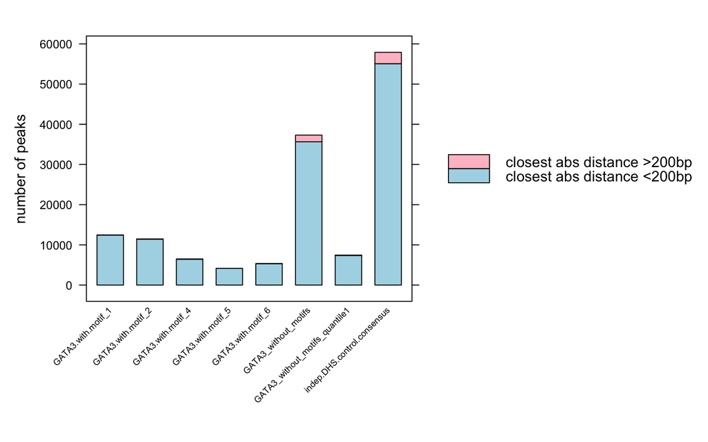

```r
df <- data.frame(
  peak_set = c("GATA3.with.motif_1", "GATA3.with.motif_2", "GATA3.with.motif_4", "GATA3.with.motif_5", "GATA3.with.motif_6", "GATA3_without_motifs", "GATA3_without_motifs_quantile1", "indep.DHS.control.consensus"),
  out_counts = c(67, 53, 90, 19, 50, 1664, 120, 2829),
  all_counts = c(12470, 11475, 6505, 4167, 5363, 37308, 7462, 57906)
)
df$in_counts=df$all_counts-df$out_counts
df$peak_set=factor(df$peak_set, levels = c("GATA3.with.motif_1", "GATA3.with.motif_2", "GATA3.with.motif_4", "GATA3.with.motif_5", "GATA3.with.motif_6", "GATA3_without_motifs", "GATA3_without_motifs_quantile1", "indep.DHS.control.consensus"))

library(lattice)
barchart(in_counts + out_counts ~ peak_set,
         stack=TRUE,
         data = df,
         horizontal = FALSE,
         col = c("lightblue", "pink"),
         key = list(space = "right", rectangles=list(pch = c(15, 15), col = c("pink", "lightblue")), text=list(c("closest abs distance >200bp", "closest abs distance <200bp"), cex=1)),
         ylab="number of peaks",
         scales=list(x=list(rot=45, cex=0.6)))
```

### 5.6.2 Violin/bw plot for 1st closest GAT distances

To see how often these deviations happen, we can quantify the 1st closest GAT distances to GATA3 peak with motifs (positive controls), and see how distances data distributed within each peak set:

**plus-GAT**

```bash
ls closest.1st.plus.GAT.*.bed
```

```
## closest.1st.plus.GAT.to.GATA3.with.motif_1.bed
## closest.1st.plus.GAT.to.GATA3.with.motif_2.bed
## closest.1st.plus.GAT.to.GATA3.with.motif_4.bed
## closest.1st.plus.GAT.to.GATA3.with.motif_5.bed
## closest.1st.plus.GAT.to.GATA3.with.motif_6.bed
## closest.1st.plus.GAT.to.GATA3_without_motifs_123456_78_161bp_mast.bed
## closest.1st.plus.GAT.to.GATA3_without_motifs_quantile1.bed
## closest.1st.plus.GAT.to.indep.DHS.control.consensus.bed
```

```r
df.plot = data.frame(matrix(nrow = 0, ncol = 4))
colnames(df.plot) = c("dis","anchor_3mer", "peak_set","abs.dis")
for (closest_1st_dis in Sys.glob(file.path("./closest.1st.plus.GAT.to.*.bed"))) {
    print(closest_1st_dis)
    anchor_3mer ="plus.GAT"
    peak_set =strsplit((strsplit(strsplit(closest_1st_dis, "/")[[1]][length(strsplit(closest_1st_dis, "/")[[1]])], 'closest.1st.plus.GAT.to.')[[1]][2]), ".bed")[[1]][1]
    print(peak_set)
    temp = as.data.frame(cbind(read.table(closest_1st_dis, header=F, comment.char='')[,11], anchor_3mer, peak_set))
    colnames(temp) = c("dis", "anchor_3mer", "peak_set")
    temp$dis=as.integer(temp$dis)
    temp$abs.dis=abs(temp$dis)
    df.plot = rbind(df.plot,temp)
}
```

```
## [1] "./closest.1st.plus.GAT.to.GATA3.with.motif_1.bed"
## [1] "GATA3.with.motif_1"
## [1] "./closest.1st.plus.GAT.to.GATA3.with.motif_2.bed"
## [1] "GATA3.with.motif_2"
## [1] "./closest.1st.plus.GAT.to.GATA3.with.motif_4.bed"
## [1] "GATA3.with.motif_4"
## [1] "./closest.1st.plus.GAT.to.GATA3.with.motif_5.bed"
## [1] "GATA3.with.motif_5"
## [1] "./closest.1st.plus.GAT.to.GATA3.with.motif_6.bed"
## [1] "GATA3.with.motif_6"
## [1] "./closest.1st.plus.GAT.to.GATA3_without_motifs_123456_78_161bp_mast.bed"
## [1] "GATA3_without_motifs_123456_78_161bp_mast"
## [1] "./closest.1st.plus.GAT.to.GATA3_without_motifs_quantile1.bed"
## [1] "GATA3_without_motifs_quantile1"
## [1] "./closest.1st.plus.GAT.to.indep.DHS.control.consensus.bed"
## [1] "indep.DHS.control.consensus"
```

```r
df.plot$peak_set = factor(df.plot$peak_set, levels = c("GATA3.with.motif_1", "GATA3.with.motif_2", "GATA3.with.motif_4", "GATA3.with.motif_5", "GATA3.with.motif_6", "GATA3_without_motifs_123456_78_161bp_mast", "GATA3_without_motifs_quantile1", "indep.DHS.control.consensus"))
summary(df.plot)
```

```
##       dis           anchor_3mer
##  Min.   :     0.0   Length:142656
##  1st Qu.:     8.0   Class :character
##  Median :    24.0   Mode  :character
##  Mean   :   585.7
##  3rd Qu.:    59.0
##  Max.   :734003.0
##
##                                       peak_set        abs.dis
##  indep.DHS.control.consensus              :57906   Min.   :     0.0
##  GATA3_without_motifs_123456_78_161bp_mast:37308   1st Qu.:     8.0
##  GATA3.with.motif_1                       :12470   Median :    24.0
##  GATA3.with.motif_2                       :11475   Mean   :   585.7
##  GATA3_without_motifs_quantile1           : 7462   3rd Qu.:    59.0
##  GATA3.with.motif_4                       : 6505   Max.   :734003.0
##  (Other)                                  : 9530
```

```r
str(df.plot)
```

```
## 'data.frame':    142656 obs. of  4 variables:
##  $ dis        : int  10 16 0 0 3 3 3 0 2 20 ...
##  $ anchor_3mer: chr  "plus.GAT" "plus.GAT" "plus.GAT" "plus.GAT" ...
##  $ peak_set   : Factor w/ 8 levels "GATA3.with.motif_1",..: 1 1 1 1 1 1 1 1 1 1 ...
##  $ abs.dis    : int  10 16 0 0 3 3 3 0 2 20 ...
```

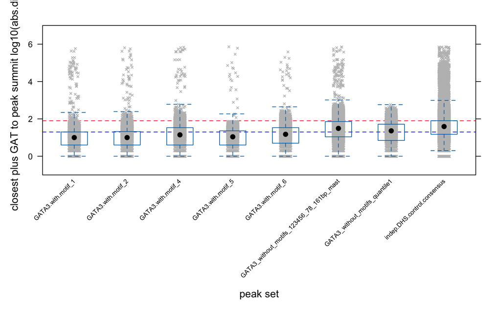

```r
library(lattice)
library(latticeExtra)

my.settings <- list(
  superpose.polygon=list(col=c("black", "grey"), border="transparent"),
  strip.background=list(col="grey80", cex = 0.6),
  strip.border=list(col="black")
)

bwplot(log10(abs.dis) ~ peak_set,
       data=df.plot,
       do.out=FALSE,
       ylim=c(-1, 7),
       par.settings = my.settings,
       panel = function(...) {
             panel.abline(h= 1.9, lty =2, col="red") # log10(80)~1.9
             panel.abline(h= 1.3, lty =2, col="blue") # log10(20)~1.3
             panel.stripplot(...,jitter.data = T, pch=4, cex=0.4, col="grey")
             #panel.violin(..., col="transparent", varwidth = FALSE)
             panel.bwplot(...)},
       scales=list(x=list(rot=45, cex=0.6)),
       xlab = "peak set",
       ylab = "closest plus GAT to peak summit log10(abs.dis)")
```

[figure not shown]

```r
my.settings <- list(
  superpose.polygon=list(col=c("black", "grey"), border="transparent"),
  strip.background=list(col="grey80", cex = 0.6),
  strip.border=list(col="black")
)
bwplot(log10(abs.dis) ~ peak_set,
       data=df.plot,
       do.out=FALSE,
       ylim=c(-1, 7),
       par.settings = my.settings,
       scales=list(x=list(rot=45, cex=0.6)),
       xlab = "peak set",
       ylab = "closest plus GAT to peak summit log10(abs.dis)",
       panel = function(...) {
             #panel.bwplot(...)
             panel.abline(h= 2.3, lty =2, col="grey40") # log10(200)~2.3
             panel.abline(h= 1.9, lty =2, col="red") # log10(80)~1.9
             panel.abline(h= 1.3, lty =2, col="blue") # log10(20)~1.3
             panel.stripplot(..., jitter.data = TRUE, pch=4, cex=0.4, col="grey")
             panel.violin(..., col="transparent", border="black", do.out = FALSE, varwidth = FALSE)
             }
       )
```

[figure not shown]

```r
bwplot(log10(abs.dis) ~ peak_set,
       data=df.plot,
       #do.out=FALSE,
       ylim=c(-1, 7),
       panel = function(..., box.ratio) {
             panel.abline(h= 1.9, lty =2, col="red") # log10(80)~1.9
             panel.abline(h= 1.3, lty =2, col="blue") # log10(20)~1.3
             panel.stripplot(...,jitter.data = T, pch=4, cex=0.4, col="grey")
             panel.violin(..., col="pink", alpha=0.4, box.ratio = box.ratio, do.out = F, border="black", varwidth = TRUE)
             },
       scales=list(x=list(rot=45, cex=0.6)),
       xlab = "peak set",
       ylab = "closest plus GAT to peak summit log10(abs.dis)")
```

[figure not shown]

```r
df.plot1=df.plot[df.plot$peak_set %in% c("GATA3.with.motif_1", "GATA3.with.motif_2", "GATA3.with.motif_4", "GATA3.with.motif_5", "GATA3.with.motif_6","indep.DHS.control.consensus"), ]

bwplot(log10(abs.dis) ~ peak_set,
       data=df.plot1,
       #do.out=FALSE,
       ylim=c(-1, 7),
       panel = function(..., box.ratio) {
             panel.abline(h= 2.3, lty =2, col="grey40") # log10(200)~2.3
             panel.abline(h= 1.9, lty =2, col="red") # log10(80)~1.9
             panel.abline(h= 1.3, lty =2, col="blue") # log10(20)~1.3
             panel.stripplot(...,jitter.data = T, pch=4, cex=0.4, col="grey")
             panel.violin(..., col="pink", alpha=0.4, box.ratio = box.ratio, do.out = F, border="black", varwidth = TRUE)
             },
       scales=list(x=list(rot=45, cex=0.6)),
       xlab = "peak set",
       ylab = "closest plus GAT to peak summit log10(abs.dis)")
```

In the negative control, the first GAT appears to be more distant from the peak summit.

**plus-ATC (same as minus-GAT)**

```bash
ls closest.1st.minus.GAT.*.bed
```

```
## closest.1st.minus.GAT.to.GATA3.with.motif_1.bed
## closest.1st.minus.GAT.to.GATA3.with.motif_2.bed
## closest.1st.minus.GAT.to.GATA3.with.motif_4.bed
## closest.1st.minus.GAT.to.GATA3.with.motif_5.bed
## closest.1st.minus.GAT.to.GATA3.with.motif_6.bed
## closest.1st.minus.GAT.to.GATA3_without_motifs_123456_78_161bp_mast.bed
## closest.1st.minus.GAT.to.GATA3_without_motifs_quantile1.bed
## closest.1st.minus.GAT.to.indep.DHS.control.consensus.bed
```

```r
df.plot = data.frame(matrix(nrow = 0, ncol = 4))
colnames(df.plot) = c("dis","anchor_3mer", "peak_set","abs.dis")
for (closest_1st_dis in Sys.glob(file.path("./closest.1st.minus.GAT.to.*.bed"))) {
    print(closest_1st_dis)
    anchor_3mer ="minus.GAT"
    peak_set =strsplit((strsplit(strsplit(closest_1st_dis, "/")[[1]][length(strsplit(closest_1st_dis, "/")[[1]])], 'closest.1st.minus.GAT.to.')[[1]][2]), ".bed")[[1]][1]
    print(peak_set)
    temp = as.data.frame(cbind(read.table(closest_1st_dis, header=F, comment.char='')[,11], anchor_3mer, peak_set))
    colnames(temp) = c("dis", "anchor_3mer", "peak_set")
    temp$dis=as.integer(temp$dis)
    temp$abs.dis=abs(temp$dis)
    df.plot = rbind(df.plot,temp)
}
```

```
## [1] "./closest.1st.minus.GAT.to.GATA3.with.motif_1.bed"
## [1] "GATA3.with.motif_1"
## [1] "./closest.1st.minus.GAT.to.GATA3.with.motif_2.bed"
## [1] "GATA3.with.motif_2"
## [1] "./closest.1st.minus.GAT.to.GATA3.with.motif_4.bed"
## [1] "GATA3.with.motif_4"
## [1] "./closest.1st.minus.GAT.to.GATA3.with.motif_5.bed"
## [1] "GATA3.with.motif_5"
## [1] "./closest.1st.minus.GAT.to.GATA3.with.motif_6.bed"
## [1] "GATA3.with.motif_6"
## [1] "./closest.1st.minus.GAT.to.GATA3_without_motifs_123456_78_161bp_mast.bed"
## [1] "GATA3_without_motifs_123456_78_161bp_mast"
## [1] "./closest.1st.minus.GAT.to.GATA3_without_motifs_quantile1.bed"
## [1] "GATA3_without_motifs_quantile1"
## [1] "./closest.1st.minus.GAT.to.indep.DHS.control.consensus.bed"
## [1] "indep.DHS.control.consensus"
```

```r
df.plot$peak_set = factor(df.plot$peak_set, levels = c("GATA3.with.motif_1", "GATA3.with.motif_2", "GATA3.with.motif_4", "GATA3.with.motif_5", "GATA3.with.motif_6", "GATA3_without_motifs_123456_78_161bp_mast", "GATA3_without_motifs_quantile1", "indep.DHS.control.consensus"))
summary(df.plot)
```

```
##       dis           anchor_3mer
##  Min.   :     0.0   Length:142656
##  1st Qu.:     9.0   Class :character
##  Median :    24.0   Mode  :character
##  Mean   :   606.2
##  3rd Qu.:    59.0
##  Max.   :890194.0
##
##                                       peak_set        abs.dis
##  indep.DHS.control.consensus              :57906   Min.   :     0.0
##  GATA3_without_motifs_123456_78_161bp_mast:37308   1st Qu.:     9.0
##  GATA3.with.motif_1                       :12470   Median :    24.0
##  GATA3.with.motif_2                       :11475   Mean   :   606.2
##  GATA3_without_motifs_quantile1           : 7462   3rd Qu.:    59.0
##  GATA3.with.motif_4                       : 6505   Max.   :890194.0
##  (Other)                                  : 9530
```

```r
str(df.plot)
```

```
## 'data.frame':    142656 obs. of  4 variables:
##  $ dis        : int  16 10 18 46 1 8 1 5 57 18 ...
##  $ anchor_3mer: chr  "minus.GAT" "minus.GAT" "minus.GAT" "minus.GAT" ...
##  $ peak_set   : Factor w/ 8 levels "GATA3.with.motif_1",..: 1 1 1 1 1 1 1 1 1 1 ...
##  $ abs.dis    : int  16 10 18 46 1 8 1 5 57 18 ...
```

[figure not shown]

```r
bwplot(log10(abs.dis) ~ peak_set,
       data=df.plot,
       #do.out=FALSE,
       ylim=c(-1, 7),
       panel = function(..., box.ratio) {
             panel.abline(h= 1.9, lty =2, col="red") # log10(80)~1.9
             panel.abline(h= 1.3, lty =2, col="blue") # log10(20)~1.3
             panel.stripplot(...,jitter.data = T, pch=4, cex=0.4, col="grey")
             panel.violin(...,col="lightblue", alpha=0.4, border="black", varwidth = TRUE)
             },
       scales=list(x=list(rot=45, cex=0.6)),
       xlab = "peak set",
       ylab = "closest minus GAT to peak summit log10(abs.dis)")
```

[figure not shown]

```r
df.plot1=df.plot[df.plot$peak_set %in% c("GATA3.with.motif_1", "GATA3.with.motif_2", "GATA3.with.motif_4", "GATA3.with.motif_5", "GATA3.with.motif_6","indep.DHS.control.consensus"), ]

bwplot(log10(abs.dis) ~ peak_set,
       data=df.plot1,
       #do.out=FALSE,
       ylim=c(-1, 7),
       panel = function(..., box.ratio) {
             #panel.abline(h= 2.3, lty =2, col="grey40") # log10(200)~2.3
             panel.abline(h= 1.9, lty =2, col="red") # log10(80)~1.9
             panel.abline(h= 1.3, lty =2, col="blue") # log10(20)~1.3
             panel.stripplot(...,jitter.data = TRUE, pch=4, cex=0.4, col="grey")
             panel.violin(..., col="lightblue", alpha=0.4, box.ratio = box.ratio, do.out = FALSE, border="black", varwidth = FALSE)
             },
       scales=list(x=list(rot=45, cex=0.6)),
       xlab = "peak set",
       ylab = "closest minus GAT to peak summit log10(abs.dis)")
```

# 6 SeqOutbias 3mer coordinates generation

## 6.1 hg38 with 10,000 read size

**3mer_df**: generating a .txt file where the first column are all 64 3mer, second column are the index, and the third column are the corresponding reversed 3mer’s index (indexrc).

```r
#define function to output the reverse compliment sequence
revcomp <- function(sequence) {
  complement_mapping <- c("A" = "T", "T" = "A", "C" = "G", "G" = "C")
  complemented_sequence <- sapply(strsplit(rev(strsplit(sequence, "")[[1]]), NULL), function(base) complement_mapping[base])
  complemented_sequence <- paste(complemented_sequence, collapse = "")
  return(complemented_sequence)
}

# 64 3mer with index
all.64 = expand.grid(rep(list(c('A','C','G','T')), 3))
all.64.df = data.frame(apply(all.64, 1 , paste, collapse = ""))
all.64.df[,1] = all.64.df[order(all.64.df[,1]),]
all.64.df[,2] = 1:64

# 64 reversed 3mer with indexrc
rev.df = data.frame(as.character(all.64.df[,1]))
rev.df[] = apply(rev.df, 1, revcomp)
rev.df[,2] = 1:64
colnames(rev.df)= c('rc', 'indexrc')


colnames(all.64.df) = c('three_mer', 'index')
all.64.df.rc = merge(all.64.df, rev.df, by.x = 'three_mer', by.y = 'rc')
write.table(all.64.df.rc, file = 'all_64_df.txt', quote=FALSE, row.names =FALSE, col.names = FALSE, sep = '\t')
```

Ref Genome is the full hg38 genome;  
Use read-size=10,000 –kmer-size=3 –plus-offset=3 –minus-offset=3

```bash
#! /bin/sh

#SBATCH --job-name=getfull3mer_10000.sh
#SBATCH -N 1
#SBATCH -n 1
#SBATCH -c 32
#SBATCH -p general
#SBATCH --qos=general
#SBATCH --mem=128G
#SBATCH --mail-type=ALL
#SBATCH --mail-user=ssun@uchc.edu
#SBATCH -o getfull3mer_10000.sh_%j.out
#SBATCH -e getfull3mer_10000.sh_%j.err

hostname
export PATH=$PATH:/home/FCAM/ssun/packages/://home/FCAM/ssun/scripts
module load genometools/1.5.10
module load ucsc_genome/2012.05.22
module load rust

genome=/home/FCAM/ssun/Genome/hg38.fa

seqOutBias seqtable ${genome} --read-size=10000 --kmer-size=3 --plus-offset=3 --minus-offset=3 --out=hg38.3.3.3.tbl
seqOutBias dump hg38.3.3.3.tbl > hg38.3.3.3.dump.txt
mkdir seqdump
mv hg38.3.3.3.dump.txt seqdump
mv all_64_df.txt seqdump
cd seqdump

while read line; do
 mer=$(echo $line | awk -F" " '{print $1}')
 idx=$(echo $line | awk -F" " '{print $2}')
 rcidx=$(echo $line | awk -F" " '{print $3}')
 echo $mer
 echo $idx
 echo $rcidx
 python /home/FCAM/ssun/scripts/dump_to_kmer.py -i hg38.3.3.3.dump.txt -p $idx -m $rcidx -s $mer
done <all_64_df.txt
```

## 6.2 T2T with 10,000 read size

T2T-CHM13v2.0/hs1 genome as the input reference genome;

```bash
#cd /home/FCAM/ssun/Genome/
wget https://hgdownload.soe.ucsc.edu/goldenPath/hs1/bigZips/hs1.fa.gz
gunzip hs1.fa.gz
```

use read-size=10,000 –kmer-size=3 –plus-offset=3 –minus-offset=3

```bash
#! /bin/sh

#SBATCH --job-name=T2T_getfull3mer_10000.sh
#SBATCH -N 1
#SBATCH -n 1
#SBATCH -c 32
#SBATCH -p general
#SBATCH --qos=general
#SBATCH --mem=128G
#SBATCH --mail-type=ALL
#SBATCH --mail-user=ssun@uchc.edu
#SBATCH -o T2T_getfull3mer_10000.sh_%j.out
#SBATCH -e T2T_getfull3mer_10000.sh_%j.err

hostname
export PATH=$PATH:/home/FCAM/ssun/packages/://home/FCAM/ssun/scripts
module load genometools/1.5.10
module load ucsc_genome/2012.05.22
module load rust

genome=/home/FCAM/ssun/Genome/hs1.fa

seqOutBias seqtable ${genome} --read-size=10000 --kmer-size=3 --plus-offset=3 --minus-offset=3 --out=hs1.3.3.3.tbl
seqOutBias dump hs1.3.3.3.tbl > hs1.3.3.3.dump.txt
mkdir seqdump
mv hs1.3.3.3.dump.txt seqdump
mv all_64_df.txt seqdump
cd seqdump

while read line; do
 mer=$(echo $line | awk -F" " '{print $1}')
 idx=$(echo $line | awk -F" " '{print $2}')
 rcidx=$(echo $line | awk -F" " '{print $3}')
 echo $mer
 echo $idx
 echo $rcidx
 python /home/FCAM/ssun/scripts/dump_to_kmer.py -i hs1.3.3.3.dump.txt -p $idx -m $rcidx -s $mer
done <all_64_df.txt
```

# 7 loop through other 3mer for GATA3 peaks without motif

### 7.0.1 Closest 3mer to peak summits (~2.5h running time)

**Goal: given a prioritized 3mer list, we can generate the closest 3mer coordinates to a given sets of peak summits.**

240225_closestBed.R:

(cd /home/FCAM/ssun/GATA3_ChIP_PRO_July2023/ChIP_final/GAT_3mer_analaysis/peak_161_without_motifs_12345678/closest_other_3mer)

```r
#!/usr/bin/env Rscript

Args=commandArgs(TRUE)
# closestBed function
bedTools.closest.mod <- function(functionstring="/home/FCAM/ssun/packages/bedtools2/bin/closestBed",bed1,bed2,opt.string="") {

  options(scipen =99) # not use scientific notation when writing out

  #write bed formatted data.frames to tempfile
  write.table(bed1,file= 'a.file.bed', quote=F,sep="\t",col.names=F,row.names=F)
  write.table(bed2,file= 'b.file.sorted.bed', quote=F,sep="\t",col.names=F,row.names=F)

  # create the command string and call the command using system()
  # the command sort a and b file by coordinates
  command1=paste('sort -k1,1 -k2,2n', 'a.file.bed', '> a.file.sorted.bed')
  cat(command1,"\n") #sort -k1,1 -k2,2n a.file.bed > a.file.sorted.bed
  try(system(command1))
  #command2=paste('sort -k1,1 -k2,2n', 'b.file.bed', '> b.file.sorted.bed')
  #cat(command2,"\n")
  #try(system(command2))

  # the command call closestBed on bed1 and bed2
  command=paste(functionstring, opt.string,"-a",'a.file.sorted.bed',"-b",'b.file.sorted.bed',">",'out.file.bed',sep=" ")
  cat(command,"\n")
  try(system(command))

  res=read.table('out.file.bed',header=F, comment.char='')

  # remove intermediate files
  command3=paste('rm', 'a.file.bed', 'a.file.sorted.bed', 'b.file.sorted.bed', 'out.file.bed')
  cat(command3,"\n")
  try(system(command3))

  colnames(res) = c(colnames(bed1), colnames(bed2), 'dis' )
  return(res)
}

dir1="/labs/Guertin/siyu/Sathyan_GATA3_ChIP_pool1_pool2/overrep_3mer/hg38_full_kmer3_rs1000/seqdump/"
dir2="/home/FCAM/ssun/GATA3_ChIP_PRO_July2023/ChIP_final/GAT_3mer_analaysis/peak_161_without_motifs_12345678/"

prioritized_triplets = c("AAA", "TAA" ,"ATA" ,"TTA", "AAT", "TAT", "GAT", "ATT", "TTT", "ATC", "AGA", "TCT", "TAG", "CTA")

library(bigWig)

for (triplet in prioritized_triplets){
  print(triplet)
  # 3mer genome coordinates
  plus.triplet.file=read.table(file = Sys.glob(file.path(paste0(dir1,"hg38.3.3.3plus.*_",triplet, ".sorted.bed"))), sep="\t", header=FALSE)

    # peak summits
    GATA3_peak_summits=center.bed(read.table(paste0(dir2, "without_motifs_123456_78_161bp_mast.bed"), header=FALSE), upstreamWindow = 0, downstreamWindow = 0)

    # closestBed--1st closest plus

    closest.1st.plus.triplet.to.peak=bedTools.closest.mod(bed1 = GATA3_peak_summits[,1:3], bed2 = plus.triplet.file, opt.string = '-d -t first')
    write.table(closest.1st.plus.triplet.to.peak,file= paste0('closest.1st.plus.',triplet,'.to.GATA3_without_motifs_123456_78_161bp_mast.bed'), quote=F,sep="\t",col.names=F,row.names=F)


}
```

runR.sh

```bash
#!/bin/bash
#SBATCH --job-name=runR.sh     # name for job
#SBATCH -N 1
#SBATCH -n 1
#SBATCH -c 8
#SBATCH -p general
#SBATCH --qos=general
#SBATCH --mem=128G
#SBATCH --mail-type=ALL
#SBATCH --mail-user=ssun@uchc.edu
#SBATCH -o runR.sh_%j.out
#SBATCH -e runR.sh_%j.err

module load R/4.1.2
Rscript 240225_closestBed.R
```

#### 7.0.1.1 STEP2: remove the closest 3mer coordinates from the whole genome 3mer coordinates on the same strand with `bedtools subtract`.

```bash
#!/bin/bash
#SBATCH --job-name=remove_1st_3mer.sh     # name for job
#SBATCH -N 1
#SBATCH -n 1
#SBATCH -c 16
#SBATCH -p general
#SBATCH --qos=general
#SBATCH --mem=200G
#SBATCH --mail-type=ALL
#SBATCH --mail-user=ssun@uchc.edu
#SBATCH -o remove_1st_3mer.sh_%j.out
#SBATCH -e remove_1st_3mer.sh_%j.err


input_dir1=/labs/Guertin/siyu/Sathyan_GATA3_ChIP_pool1_pool2/overrep_3mer/hg38_full_kmer3_rs1000/seqdump/
input_dir2=/home/FCAM/ssun/GATA3_ChIP_PRO_July2023/ChIP_final/GAT_3mer_analaysis/peak_161_without_motifs_12345678/closest_other_3mer/


prioritized_triplets=("AAA" "TAA" "ATA" "TTA" "AAT" "TAT" "GAT" "ATT" "TTT" "ATC" "AGA" "TCT" "TAG" "CTA")

module load bedtools

for triplet in "${prioritized_triplets[@]}"
do
  echo $triplet

    # plus
    awk '{print $4, $5, $6, $7, $8, $9, $10}' ${input_dir2}closest.1st.plus.${triplet}.to.GATA3_without_motifs_123456_78_161bp_mast.bed  | awk '{$1=$1}1' OFS="\t" | uniq | sort -k1,1 -k2,2n > closest.1st.plus.${triplet}.to.GATA3_without_motifs_123456_78_161bp_mast.uniq.sorted.bed

    bedtools subtract -a ${input_dir1}hg38.3.3.3plus.*${triplet}.sorted.bed -b closest.1st.plus.${triplet}.to.GATA3_without_motifs_123456_78_161bp_mast.uniq.sorted.bed -f 1.00 -s > hg38.3.3.3plus.${triplet}_without_1st_plus_${triplet}_to_GATA3_without_motifs_123456_78_161bp_mast.bed

    rm closest.1st.plus.${triplet}.to.GATA3_without_motifs_123456_78_161bp_mast.uniq.sorted.bed

done
```

#### 7.0.1.2 STEP3

240226_closestBed_peak_without_mot.R

```r
#!/usr/bin/env Rscript

Args=commandArgs(TRUE)

bedTools.closest.mod <- function(functionstring="/home/FCAM/ssun/packages/bedtools2/bin/closestBed",bed1,bed2,opt.string="") {

  options(scipen =99) # not use scientific notation when writing out

  #write bed formatted data.frames to tempfile
  write.table(bed1,file= 'a.file.bed', quote=F,sep="\t",col.names=F,row.names=F)
  write.table(bed2,file= 'b.file.sorted.bed', quote=F,sep="\t",col.names=F,row.names=F)

  # create the command string and call the command using system()
  # the command sort a and b file by coordinates
  command1=paste('sort -k1,1 -k2,2n', 'a.file.bed', '> a.file.sorted.bed')
  cat(command1,"\n") #sort -k1,1 -k2,2n a.file.bed > a.file.sorted.bed
  try(system(command1))
  #command2=paste('sort -k1,1 -k2,2n', 'b.file.bed', '> b.file.sorted.bed')
  #cat(command2,"\n")
  #try(system(command2))

  # the command call closestBed on bed1 and bed2
  command=paste(functionstring, opt.string,"-a",'a.file.sorted.bed',"-b",'b.file.sorted.bed',">",'out.file.bed',sep=" ")
  cat(command,"\n")
  try(system(command))

  res=read.table('out.file.bed',header=F, comment.char='')

  # remove intermediate files
  command3=paste('rm', 'a.file.bed', 'a.file.sorted.bed', 'b.file.sorted.bed', 'out.file.bed')
  cat(command3,"\n")
  try(system(command3))

  colnames(res) = c(colnames(bed1), colnames(bed2), 'dis' )
  return(res)
}

library(bigWig)

# List of prioritized triplets
prioritized_triplets <- c("AAA", "TAA", "ATA", "TTA", "AAT", "TAT", "GAT", "ATT", "TTT", "ATC", "AGA", "TCT", "TAG", "CTA")

# List to store non-redundant 6mers
all_6mers <- list()
for (i in 1:length(prioritized_triplets)) {
  for (j in 1:length(prioritized_triplets)) {
    pair <- c(prioritized_triplets[i], prioritized_triplets[j])
    # Combine triplets to form a 6mer
    sixmer <- paste(pair, collapse = "")
    all_6mers <- c(all_6mers, list(sixmer))

  }
}

# Create data frame with first 3 bases and last 3 bases
first_3_bases <- substr(all_6mers, 1, 3)
last_3_bases <- substr(all_6mers, 4, 6)
df <- data.frame(First_3_bases = first_3_bases, Last_3_bases = last_3_bases)


dir1="/home/FCAM/ssun/GATA3_ChIP_PRO_July2023/ChIP_final/GAT_3mer_analaysis/peak_161_without_motifs_12345678/closest_other_3mer/"
dir2="/home/FCAM/ssun/GATA3_ChIP_PRO_July2023/ChIP_final/GAT_3mer_analaysis/peak_161_without_motifs_12345678/closest_other_3mer/closest_2nd_other_3mer/"


# DHS regions
for (i in 1:nrow(df)){
    pattern1=df[i,1]
    pattern2=df[i,2]
    # anchor position: closest +/- pattern1
    print(pattern1)
    closest_plus_3mer_to_peak=fiveprime.bed(read.table(paste0(dir1, "closest.1st.plus.", pattern1, ".to.GATA3_without_motifs_123456_78_161bp_mast.bed"), header=FALSE)[,4:11], upstreamWindow = 0, downstreamWindow = 0)

    # query 3mer coordinates on genome (without the overlapped closest 3mer coordinates)
    print(pattern2)
    plus.3mer.file=fiveprime.bed(read.table(file = paste0(dir2, "hg38.3.3.3plus.", pattern2, "_without_1st_plus_", pattern2, "_to_GATA3_without_motifs_123456_78_161bp_mast.bed"), sep="\t", header=FALSE), upstreamWindow = 0, downstreamWindow = 0)

  # 2nd closest plus 3mer to closest plus 3mer
  closest.2nd.plus.3mer.to.1st.plus.3mer=bedTools.closest.mod(bed1 = closest_plus_3mer_to_peak[,1:3], bed2 = plus.3mer.file, opt.string = '-d -t first')


  write.table(closest.2nd.plus.3mer.to.1st.plus.3mer, file= paste0("closest.2nd.plus.", pattern2, ".to.1st.plus.", pattern1, ".to.GATA3_without_motifs_123456_78.bed"), quote=F,sep="\t",col.names=F,row.names=F)
  }
```

runR_peak_without_mot.sh

```bash
#!/bin/bash
#SBATCH --job-name=runR_peak_without_mot.sh    # name for job
#SBATCH -N 1
#SBATCH -n 1
#SBATCH -c 8
#SBATCH -p general
#SBATCH --qos=general
#SBATCH --mem=128G
#SBATCH --mail-type=ALL
#SBATCH --mail-user=ssun@uchc.edu
#SBATCH -o runR_peak_without_mot.sh_%j.out
#SBATCH -e runR_peak_without_mot.sh_%j.err

hostname
mkdir peak_without_mot
cd peak_without_mot

module load R/4.1.2
Rscript ../240226_closestBed_peak_without_mot.R
```